# La “Calidad de Vida” en Illes Balears: una visión multidimensional

¿En qué se diferencia Illes Balears del resto de España? Un análisis de 82 indicadores de calidad de vida (2004–2024)

02 de noviembre de 2026

**Autores:**

**Dr. Luis Álvarez León**. Doctor en Matemática Aplicada (UCM). Catedrático ULPGC

**Dr. Bartomeu Coll Vicens**. Doctor en Ciencias Matemáticas. Catedrático UIB. Área Ciencias Matemáticas e Informática. Matemática Aplicada.

**Jose Vicens Colom.** Economista. Máster en Dirección Financiera. Director del Cercle d’Economia de Mallorca.

**Dr. José Mª Vicens Gómez.** Doctor en Medicina. Especialista Medicina Interna. Experto en Estadística de la Salud y Administración Sanitaria. Ex-presidente del Cercle d’Economia de Mallorca (2018-2026). Académico RAMIB.

# Introducción y justificación

Una de las dificultades fundamentales en la investigación social, o en cualquier tentativa de hallar respuestas inteligentes a problemas diversos —*urgentes o no*—, es el hecho de que en el mundo real los procesos que queremos estudiar, como la salud, el bienestar o la “calidad de vida”, deben abordarse en la actualidad con un análisis riguroso de medidas múltiples, las cuales, además, suelen estar interrelacionadas entre sí como en una maraña difícil de desentrañar. Si adicionalmente se pretende comparar entre distintos individuos, territorios o regiones, la complejidad se multiplica o se hace imposible. En este ámbito, como en casi todos, la realidad que vivimos es siempre compleja, multiconceptual y multidimensional, lo que ha llevado a la implantación y aplicación, cada vez más frecuente, de teorías o técnicas matemáticas contrastadas, clásicas o innovadoras que, con el desarrollo de las nuevas tecnologías, la revolución en la potencia de cálculo y en la representación gráfica, y con el impulso de las denominadas “inteligencias artificiales”, nos facilitan hoy los análisis multivariantes o multivariables —*reducción de variables, agrupación, relaciones de dependencia o construcción de modelos*— que nos permiten una aproximación más respetuosa y honesta a la realidad. La medición del progreso, del bienestar, no puede basarse en un solo indicador como el PIB, igual que la salud de una persona, o de un colectivo, no se resume en un único dato (temperatura o peso). Y seguramente si hiciéramos una pequeña encuesta en un grupo de personas sobre lo que consideran bienestar las respuestas serían diversas, según los diferentes indicadores que definen este concepto.

En este contexto, en las últimas décadas se han sucedido distintas iniciativas en el ámbito internacional (OCDE, Eurostat) en relación con la medición de la calidad de vida, una materia que ha venido ganando importancia en el mundo académico. El Instituto Nacional de Estadística (INE) publica, desde el año 2017, el denominado **“Indicador multidimensional de calidad de vida”**, basado en diversos indicadores que se agrupan en nueve dimensiones. Para poder analizar, desde esta perspectiva, la “calidad de vida en Baleares” hemos estudiado, con diferentes técnicas matemáticas y de representación gráfica, series de 82 indicadores oficiales que se agrupan, finalmente, en varios componentes principales que abarcan los diferentes aspectos de la “calidad de vida”, en las 17 comunidades autónomas —con especial énfasis en las Islas Baleares—, siguiendo el esquema multicomponente y multidimensional (17 territorios × 82 indicadores × 21 años) que sigue:

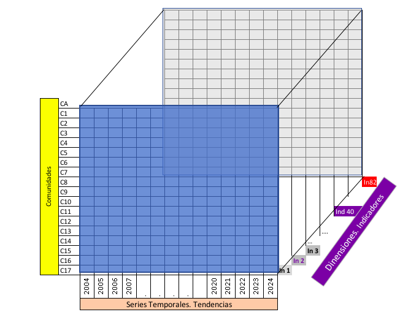

**Figura 1.** Esquema de los datos del informe: 17 comunidades autónomas × 21 años (2004–2024) × 82 indicadores.

Aprovechando esta abundante información oficial, en la segunda parte de este informe (apartados 8 a 10) analizamos también las posibles rutas que pueden conducir a la mejora de la calidad de vida en nuestro territorio: mediante modelos de relaciones de dependencia, estudiamos cómo se encadenan la formación, el empleo, la renta y el bienestar, cómo afecta el precio de la vivienda y si Baleares sigue las mismas pautas que el resto de comunidades.

# 1 Resumen: las ideas principales

Antes de entrar en los detalles, esto es lo que dicen los datos. Cada afirmación se justifica en el apartado correspondiente. Las cinco primeras ideas narran (explican) en qué se diferencia Illes Balears del resto de España y hacia dónde va (apartados 3 a 7); las cuatro últimas, qué relaciona unos indicadores con otros (apartados 8 a 10).

1. **Illes Balears tiene mucho empleo y buena salud subjetiva, pero una renta que no destaca.** Es la primera de las 17 comunidades autónomas en tasa de empleo, en salud autopercibida “muy buena” y en satisfacción media con el trabajo, y la que *menos* enfermedad crónica y *menos* necesidades médicas sin atender tiene de toda España, aunque su esperanza de vida ocupa el lugar 11 de las 17. Parte de esas ventajas se explican, probablemente, porque su población es más joven que la media (el apartado 4 lo detalla). Su renta por persona, en cambio, está en la zona media: casi todos los años entre el **puesto 5 y el 8** de 17, y solo uno (2018) entre las cuatro primeras.
2. **Junto con Madrid, tiene la vivienda más cara de España.** Su metro cuadrado cuesta casi el **doble** que la media de las demás comunidades y casi **cuatro veces** más que en la más barata (Extremadura). Como su renta no está a esa altura, es la comunidad donde comprar vivienda exige **más esfuerzo en relación con lo que se gana**, y lo es todos los años desde 2019. Ese es el verdadero desequilibrio balear: unos precios de comunidad rica con rentas de comunidad media. Un dato ayuda a entenderlo: según el Colegio de Registradores de la Propiedad, en 2025 el 29,9 % de las compraventas de vivienda en Illes Balears las hicieron compradores de nacionalidad extranjera, más del doble que en el conjunto de España (13,8 %).
3. **Y además es donde más rápido sube.** Descontada la inflación, la vivienda en Illes Balears vale hoy un **18 % más** que en 2007, mientras que la renta de sus hogares ha subido un 6 %. En el conjunto de España, en cambio, vale un **27 % menos** que entonces (no es un efecto del peso de las comunidades menos pobladas: descontada la inflación, 15 de las 17 comunidades valen hoy menos que en 2007, entre ellas Cataluña, un 40 % menos, País Vasco, un 34 %, y Madrid, un 17 %), y solo Illes Balears y Canarias están por encima de aquel nivel. Es la evolución en la que Illes Balears más se aparta del resto del país. El alquiler repite el patrón: +23 % desde 2011, también descontada la inflación, la mayor subida de España.
4. **Mientras tanto, lo que produce la economía balear por habitante lleva 24 años sin moverse.** El PIB per cápita real creció un **+0,7 % entre 2000 y 2023**, la peor cifra de España (la media nacional subió un 19 %). No es que la economía no crezca: en total creció un 44 %, algo más que la española. Es que la población creció casi lo mismo (**+43 %, el mayor aumento de España**), y al repartir lo producido entre muchos más habitantes la cifra por persona, el PIB por habitante, se ha quedado donde estaba. Tampoco es un efecto de la pandemia: hasta 2019 la cifra era **+0,1 %**. Junto con el punto anterior, esa es la tijera que define el problema: **la vivienda sube más rápido que en ninguna parte mientras la riqueza por habitante no avanza**.
5. **Su otro punto débil, persistente, es la educación.** Es la segunda comunidad con más **abandono escolar temprano** (el 18 % de los jóvenes de 18 a 24 años ha dejado de estudiar con, como mucho, la ESO, frente al 12 % de media en el resto de comunidades) y la que tiene menos jóvenes con estudios superiores. La distancia con el resto de España se ha acortado mucho en veinte años, pero no se ha cerrado, y desde 2021 el abandono ha vuelto a subir. Entre los adultos de 25 a 64 años, solo el 34,6 % tiene estudios superiores, frente al 40,7 % de España (puesto 14 de 17); es el indicador de educación que más pesa en el eje de nivel socioeconómico del apartado 6, y en el que Illes Balears queda más lejos de las comunidades a las que se parece por renta.

**¿Y a qué comunidades se parece Illes Balears?**

Un algoritmo que agrupa las 17 comunidades, sin saber cuál es cada cuál, coloca a Illes Balears junto a Cataluña, Madrid, Navarra y País Vasco: la España de mayor nivel socioeconómico. Pero dentro de ese grupo Illes Balears es la de **renta más baja**, la de **menos producción por habitante** y la de **menos titulados superiores** y, al mismo tiempo, la de **vivienda más cara**, empatada con Madrid. Comparte los costes del grupo sin compartir del todo sus ventajas económicas.

**Un matiz importante, porque parece una contradicción.** El porcentaje de población con *gasto elevado* en vivienda es de los que más rápido **baja** en Illes Balears, al mismo tiempo que el *precio* del metro cuadrado es el que más rápido **sube**. No se contradicen: miden cosas distintas. El primero refleja lo que pagan quienes ya tienen casa (probablemente muchos, propietarios con hipotecas antiguas); el segundo, lo que cuesta entrar hoy. El apartado 5 vuelve sobre esto.

**¿Qué influye en qué o cómo se interrelacionan los indicadores?**

El análisis de rutas de los apartados 8 a 10, que estudia cómo se relacionan los indicadores entre sí y si Illes Balears sigue las mismas reglas que el resto, añade cuatro ideas más:

6. **La formación, el empleo, la renta y el bienestar forman una cadena que se ve con claridad en las 17 comunidades.** Donde hay más titulados superiores hay menos paro y más renta, y entre las dos cosas (formación y paro) explican el **87 %** de las diferencias de renta entre comunidades. La renta se relaciona a su vez con la satisfacción vital, pero no directamente: el camino pasa por la **confianza en los demás**. Las comunidades con más renta tienen personas que confían más en los demás, y esas comunidades son las más satisfechas con su vida. Una vez que se tiene en cuenta la confianza, la carencia material ya no añade nada para predecir la satisfacción.
7. **Illes Balears encaja en esa cadena, con un matiz: tiene menos paro del que le “correspondería” por su nivel de formación.** Con su porcentaje de titulados superiores, las demás comunidades harían esperar un paro de alrededor del 15 %, y Illes Balears tiene un 10,6 %. Es la otra cara de su déficit educativo (idea 5): la huella de una economía turística que genera mucho empleo que no exige estudios superiores. A partir de ahí, su renta, su confianza y su satisfacción son las que el modelo espera.
8. **En vivienda, el precio sube con la renta *y* con el crecimiento de la población** (esta segunda relación, eso sí, se apoya en buena parte en el propio caso balear). Y la renta tiene dos efectos opuestos sobre el esfuerzo que supone la vivienda: encarece los precios (lo que aumenta el esfuerzo) pero también da más capacidad de pago (lo que lo reduce).
9. **El precio de la vivienda en Illes Balears va mucho más allá de lo que “le tocaría”.** Ni su renta ni el fuerte crecimiento de su población (idea 4) bastan para explicarlo: con esas dos cifras, y según lo que ocurre en las otras 16 comunidades, a Illes Balears le correspondería un precio medio de vivienda de unos **2.246 €/m²** (en euros de 2024, es decir, descontada la inflación); en Illes Balears cuesta **3.271 €/m²**, un **46 % más**. Solo una comunidad se aparta más de lo esperado: Canarias (+58 %). Que las dos comunidades más caras de lo que les correspondería sean los dos archipiélagos es un indicio (no una prueba) de que la insularidad y el turismo pesan en el precio. Esa parte del precio no la explican ni la renta ni la población, y apunta a factores que no están en estos datos (la demanda turística y extranjera, la escasez de suelo de un territorio insular, y la fuerte demanda de segunda vivienda de extranjeros).

**Qué NO dicen las rutas.** Un análisis de rutas **no demuestra causas**. Las flechas son hipótesis razonables que el analista dibuja *antes* de mirar los resultados; el análisis dice cuánto pesaría cada flecha *si* el esquema fuera correcto, y si los datos contradicen o no el esquema. Además, se trabaja con solo 17 comunidades, lo que obliga a usar modelos pequeños y a leer los números con prudencia. El apartado 8 explica todo esto con detalle.

# 2 De qué va este informe

## 2.1 El marco: los Indicadores de Calidad de Vida del INE

Medir “la calidad de vida” de un territorio con una sola cifra es imposible: depende de la salud —objetiva y subjetiva—, del dinero —riqueza, patrimonio, renta…—, del trabajo, de la vivienda, de la seguridad, del entorno… Por eso, promovido por diversas iniciativas internacionales, el Instituto Nacional de Estadística (INE) publica anualmente los denominados **Indicadores de Calidad de Vida (ICV)**, que no son un número único sino un *conjunto* de indicadores organizados en nueve dimensiones temáticas, siguiendo el mismo marco que usa Eurostat para toda la Unión Europea. A partir de 55 de ellos, el INE elabora además desde 2017 un índice único, el Indicador Multidimensional de Calidad de Vida (IMCV), que los resume en una sola cifra. De las nueve dimensiones, la de *Gobernanza y derechos básicos* no tiene ningún dato por comunidad autónoma posterior a 2022, así que este informe trabaja con ocho. La Encuesta Europea de Calidad de Vida (EQLS), de Eurofound, es otra herramienta de seguimiento para captar la calidad de vida en múltiples dimensiones.

Este informe analiza los 82 indicadores disponibles **desagregados por comunidad autónoma** y que siguen actualizándose (datos hasta 2023 o 2024 según el indicador), repartidos en estas dimensiones:

**Tabla 1.** Número de indicadores del informe en cada dimensión de los Indicadores de Calidad de Vida.

| Dimensión del ICV | Nº de indicadores |
| --- | --- |
| Condiciones materiales de vida | 22 |
| Salud | 19 |
| Educación | 18 |
| Trabajo | 13 |
| Entorno y medioambiente | 5 |
| Seguridad física y personal | 3 |
| Experiencia general de la vida | 1 |
| Ocio y relaciones sociales | 1 |

Fuentes: INE (Indicadores de Calidad de Vida, Contabilidad Regional de España e IPC, este último para descontar la inflación), Colegio de Registradores de la Propiedad y SERPAVI (Ministerio de Vivienda y Agenda Urbana). Elaboración propia.

**¿De dónde salen exactamente estos 82 indicadores?** El ICV del INE es un catálogo grande y heterogéneo, así que no todo entra: se aplicaron dos criterios de selección y un paso de desagregación.

**Primer filtro: que el dato exista por comunidad autónoma.** El catálogo del ICV tiene **480 tablas**, pero la mayoría solo se publica para el total nacional o por sexo y edad. Solo **58** están desagregadas por comunidad autónoma, que es la unidad de comparación de este informe.

**Segundo filtro: que siga vivo.** Solo se conservan indicadores cuyo último dato disponible es de **2023 o posterior**. Se descartan series que el INE ha dejado de actualizar. Quedan **42** tablas.

**Y un paso de desagregación: una tabla no es un indicador.** Muchas tablas del ICV no contienen un único número por comunidad y año, sino **varias categorías de respuesta de la misma pregunta de encuesta**. “Salud autopercibida”, por ejemplo, es una sola tabla pero cinco cifras distintas (muy buena, buena, regular, mala, muy mala), y cada una cuenta algo diferente. Tratarlas como un único indicador obligaría a elegir una y tirar el resto, o a promediar categorías que no son promediables.

Por eso cada categoría se separa como **indicador aparte**. En este contexto, aparte no quiere decir independiente: las categorías de una misma pregunta suman 100 %, así que si una sube, alguna otra tiene que bajar. El apartado 6 tiene esto en cuenta. De las 42 tablas, 24 tienen una sola cifra y 18 se desdoblan en varias —entre 2 y 8—, lo que da en total **85 indicadores**. El caso extremo es “Nivel de formación alcanzado por la población adulta”, que cruza dos grupos de edad (25–64 y 65+) con cuatro niveles formativos: 8 indicadores de una sola tabla.

De esos 85 se quitan 6 que no miden la calidad de vida sino el tamaño de la muestra de las mediciones de contaminación (población y estaciones consideradas), y quedan 79. Añadiendo a estos indicadores los tres que no salen de una tabla del ICV —dos de precio de la vivienda y uno de producción económica, que se explican justo debajo—, se llega a los 82 de este informe.

**Tres indicadores que no son de una tabla del ICV, y por qué.** El ICV mide la vivienda solo de forma *indirecta* (qué porcentaje de hogares dedica una parte excesiva de su renta a pagarla, cuántos viven con falta de espacio, cuánta gente está satisfecha con la suya, pero en ningún sitio dice **cuánto cuesta**) y no incluye ningún indicador del tamaño de la economía por habitante. Para una comunidad en la que el precio de la vivienda es el asunto público dominante, esas ausencias dejan fuera piezas centrales, así que se han añadido tres indicadores más:

- **Precio de compraventa** (€/m²), del **Colegio de Registradores de la Propiedad**: precio medio de las compraventas efectivamente inscritas en el registro, no de tasaciones ni de anuncios. Serie trimestral desde 2007, aquí promediada por año.
- **Precio de alquiler** (€/m² al mes), del **SERPAVI** del Ministerio de Vivienda y Agenda Urbana: explotación de las fuentes tributarias de los contratos de alquiler de vivienda habitual. Serie anual desde 2011. Se usa la *mediana* de vivienda colectiva (pisos).
- **PIB per cápita real** (euros constantes de 2023), de la **Contabilidad Regional de España** del INE. El INE solo publica por separado el índice de volumen encadenado del PIB total (la variación “real”, ya sin el efecto de los precios) y el PIB nominal, así que aquí se combinan ambos con la población de cada comunidad para obtener un PIB per cápita en términos reales — sin aplicar ningún deflactor de precios propio, solo piezas ya oficiales del INE (el Anexo C explica el cálculo completo).

Los tres se han clasificado en la dimensión **“Condiciones materiales de vida”**: los dos de vivienda porque es donde el marco del ICV sitúa el resto de indicadores de ese tema, y el PIB per cápita porque mide el nivel económico general de una comunidad, igual que la renta. La columna *Fuente* del Anexo B identifica el origen de cada uno de los 82 indicadores.

**Renta y precios de la vivienda, sin el efecto de la inflación.** Que una renta pase de 16.000 a 20.000 € en quince años no quiere decir que los hogares vivan un 25 % mejor si en ese tiempo los demás precios también han subido. Por eso los cuatro indicadores que se miden en euros —renta media, renta mediana, precio de compraventa y precio de alquiler— se presentan **descontada la inflación** (se dice que están *deflactados*, o en *euros constantes*), con el Índice de Precios de Consumo (IPC) que el INE publica para cada comunidad:

- **El último año de cada serie queda tal cual**, y los anteriores se expresan **en euros de ese último año**, es decir, en euros de hoy. Por ejemplo, el metro cuadrado en Illes Balears costó 2.102 € en 2007; a precios de 2024 son 2.942 €, que es la cifra que usa este informe (el de 2024, 3.467 €, no cambia). Así las cifras recientes coinciden con las que se publican, y cuando una de estas series sube, es que la vivienda se ha encarecido (o la renta ha crecido) de verdad, y no solo por la inflación.
- **Cada comunidad se ajusta con su propio IPC**, porque la inflación no ha sido igual en todas: entre 2007 y 2024 fue del +34 % en Canarias, del +42 % en Cataluña y del +40 % en Illes Balears.
- **Una limitación**: el IPC mide cómo cambian los precios *dentro* de cada comunidad con el paso del tiempo, no si vivir en una es más caro que en otra. Estas cifras quitan la inflación, pero no dicen que 1.000 € den para lo mismo en Palma que en otras capitales peninsulares.

El PIB per cápita ya viene en euros constantes por su propio método, también anclado en su último año (2023), y el resto de indicadores son porcentajes o tasas, que no necesitan este ajuste.

## 2.2 La pregunta

> **¿En qué se diferencia realmente Illes Balears del resto de España, y hacia dónde se está moviendo?**

Parece una pregunta sencilla, pero tiene trampa. Si se compara Illes Balears con la media nacional indicador por indicador, salen 82 comparaciones distintas: algunas diferencias serán grandes de verdad y otras serán ruido. Y una diferencia, además, puede ser llamativa *hoy* pero estar desapareciendo, o al revés: un indicador puede parecer normal ahora mismo y estar empeorando a toda velocidad.

Por eso el informe ataca la pregunta desde cuatro ángulos complementarios, cada uno respondiendo a algo que los otros no ven.

Y esa pregunta deja abierta una segunda, a la que se dedican los apartados 8 a 10:

> **¿Cómo se relacionan unos indicadores con otros, y si Illes Balears sigue las mismas reglas que el resto?**

Saber que Illes Balears tiene mucho empleo, pocos titulados superiores y una vivienda muy cara no dice si esas cosas están conectadas o interrelacionadas, ni si lo están igual que en las demás comunidades. Para eso se usa un *análisis de rutas*.

## 2.3 Guía de lectura

**Tabla 2.** Guía de lectura: qué pregunta responde cada apartado del informe.

| Apartado | Pregunta que responde | Por qué es interesante |
| --- | --- | --- |
| 3. Panorama | ¿Cómo han evolucionado los 82 indicadores desde 2004? | Es la vista completa, sin filtrar. Permite ver con los ojos la forma de cada serie antes de que ningún cálculo resuma nada. |
| 4. Nivel | ¿Dónde está Illes Balears **hoy** respecto a las demás comunidades? | Identifica en qué es Illes Balears realmente excepcional, separando lo que es una diferencia grande de lo que es ruido. |
| 5. Tendencia | ¿Hacia dónde se **mueve**, y más rápido o más lento que el resto? | Un buen nivel que se está deteriorando es una noticia distinta de un buen nivel estable. Esto no se ve en el apartado anterior. |
| 6. PCA | Si miramos los 82 indicadores **a la vez**, ¿cuáles son los grandes ejes que diferencian a las comunidades? | Resume 82 cifras en unos pocos ejes. Descubre que muchos indicadores dicen lo mismo con otras palabras. |
| 7. Grupos | ¿A qué comunidades **se parece** Illes Balears? | Contrasta el retrato individual: si un algoritmo ciego agrupa a Illes Balears con Madrid y Cataluña, parte de lo que parecía singular es en realidad el perfil de un tipo de comunidad. |
| 8. Rutas | ¿Cómo se pasa de “estos indicadores van juntos” a “por dónde llega la influencia de uno a otro”? | Las correlaciones dicen qué va junto, pero no por qué. Este apartado explica la técnica que lo intenta, qué puede decir y qué no, y con qué datos trabaja. |
| 9. Modelo 1 | ¿Por qué caminos se relaciona la formación con el bienestar, y sigue Illes Balears esa cadena? | Muestra por dónde podría llegar la influencia de la formación, el paro y la renta hasta la satisfacción vital, y en qué punto de esa cadena se aparta Illes Balears. |
| 10. Modelo 2 | ¿Qué explica el precio de la vivienda, y cuánto se aparta Illes Balears de lo que le correspondería? | Separa la parte del precio balear que explican su renta y su crecimiento de población de la que no explica ninguna de las dos. |

**Una aclaración sobre el enfoque.** Los apartados 4 a 10 trabajan con las **17 comunidades autónomas** (se excluyen Ceuta y Melilla, que son ciudades autónomas y no comunidades, y el total nacional, que es un agregado y no un caso comparable): en los apartados 4 y 5 eso significa medir a Illes Balears contra las otras 16. El apartado 3, en cambio, compara Illes Balears con el **total nacional**, que es la referencia más intuitiva para ver una evolución. Son dos referencias distintas a propósito: si nos preguntamos “¿es Illes Balears atípica?” hace falta el grupo de comparación completo; y si por el contrario la pregunta es “¿cómo ha evolucionado?” basta la media del país.

## 2.4 Cómo se evitan los espejismos estadísticos

Los datos del ICV vienen en buena parte de encuestas, y las encuestas oscilan de un año a otro por motivos que no tienen que ver con un cambio real (una muestra algo distinta, un año excepcional). Si se toma un único año como “la foto”, esa oscilación puede inventar diferencias que no existen. Este informe toma dos precauciones, y las usa de forma consistente en todos los apartados y con todos los indicadores:

**Para el nivel: la mediana de los últimos 5 años**, no el último año suelto. La *mediana* es el valor central: si de cinco años uno es disparatado, la mediana ni se entera (la media, en cambio, se desplazaría). Es una forma barata de preguntar “¿cuánto vale esto normalmente?” en vez de “¿cuánto valió el año pasado?”.

**Para la tendencia: el estimador de Theil-Sen**, no una recta de regresión clásica. La idea es bonita y fácil: en vez de ajustar una recta que minimice distancias, se calcula la pendiente **entre cada pareja de años posible** y se toma la *mediana* de todas esas pendientes. Si un año es atípico, solo estropea las parejas en las que él participa, y la mediana lo ignora. Una regresión clásica, en cambio, puede quedar inclinada entera por culpa de un único punto. Es el efecto de los valores atípicos, cuyo impacto hay que mitigar.

Hay además dos límites que ninguna de estas precauciones elimina, y conviene tenerlos presentes desde el principio:

- **Algunos indicadores tienen un solo año reciente.** Las preguntas de satisfacción con la vivienda y con el trabajo proceden de módulos que la encuesta solo incluye cada varios años; el último es de 2023. Para ellos no hay “mediana de cinco años” posible: la cifra es la de ese único año, con todo su ruido.
- **La ventana 2020–2024 incluye la pandemia**, y la pandemia golpeó a Illes Balears más que a ninguna otra comunidad por su dependencia del turismo. La mediana aguanta bien uno o dos años raros, pero en los indicadores económicos (renta, PIB) deja a Illes Balears algo más abajo de lo que muestran los años normales. Cuando eso cambia una conclusión, el texto lo dice.

# 3 Panorama: dos décadas de evolución

Este apartado es la vista sin filtrar: los 82 indicadores, cada uno con la serie de España (azul) y la de Illes Balears (naranja) superpuestas. Los gráficos son **interactivos**: se puede acceder a cada dimensión del ICV haciendo clic en su nombre, empezando por “3.1 Salud” y al pasar el ratón por encima de cualquier punto de las gráficas aparece el valor exacto, el año y las unidades.

Cada pestaña es una dimensión del ICV. Conviene empezar por aquí, antes de ningún cálculo: mirar las formas permite juzgar por uno mismo si lo que digan después los números encaja con lo que se ve.

**Cómo leer estos gráficos.** La escala horizontal nos da la evolución con el tiempo medida en años. Por otra parte, cada panel tiene su **propia escala vertical**, porque los indicadores se miden en cosas distintas (porcentajes, euros, µg/m³, tasas por 100.000 habitantes…). Eso significa que aquí hay que comparar **formas**, no alturas: si la línea naranja va por encima de la azul, Illes Balears está por encima de España en ese indicador; si se separan con el tiempo, la diferencia está creciendo. El fondo del título de cada panel dice si es bueno o malo que ese indicador suba: **verde**, subir es bueno; **morado**, subir es malo; **sin color**, depende (los mismos colores que la columna *Indicador* de las tablas de los apartados 4 y 5, y el criterio de cada uno está en el Anexo B). Así, una línea naranja por encima de la azul en un panel verde es una buena noticia para Illes Balears, y en uno morado, una mala. Para comparar magnitudes entre indicadores distintos están las tablas de los apartados siguientes. La renta y los precios de vivienda aparecen descontada la inflación, en euros constantes (ver el Apartado 2).

**Una salvedad sobre el panel de *Precio alquiler*** (en “Condiciones materiales de vida”): SERPAVI publica el dato por comunidad autónoma pero **no un agregado nacional**, así que la línea azul de ese panel no es el “precio medio en España” sino la **media simple de las comunidades y ciudades autónomas**, con todas pesando igual. Al no estar ponderada por población no representa la media nacional, así que conviene leerla como “la comunidad típica”, no como “España”. Además, Navarra (desde 2021) y País Vasco (solo 2024) entran en esa media a mitad de la serie, y eso la mueve un poco por sí solo. Sirve para ver la *forma* de la evolución y la distancia relativa de Illes Balears, que es justo para lo que se usa aquí.

## 3.1 Salud

[interactive chart not shown]

**Figura 2.** Evolución de los indicadores de la dimensión Salud: Illes Balears (naranja) frente a España (azul).

## 3.2 Condiciones materiales de vida

[interactive chart not shown]

**Figura 3.** Evolución de los indicadores de la dimensión Condiciones materiales de vida: Illes Balears (naranja) frente a España (azul).

## 3.3 Educación

[interactive chart not shown]

**Figura 4.** Evolución de los indicadores de la dimensión Educación: Illes Balears (naranja) frente a España (azul).

## 3.4 Trabajo

[interactive chart not shown]

**Figura 5.** Evolución de los indicadores de la dimensión Trabajo: Illes Balears (naranja) frente a España (azul).

## 3.5 Entorno y medioambiente

[interactive chart not shown]

**Figura 6.** Evolución de los indicadores de la dimensión Entorno y medioambiente: Illes Balears (naranja) frente a España (azul).

## 3.6 Seguridad física y personal

[interactive chart not shown]

**Figura 7.** Evolución de los indicadores de la dimensión Seguridad física y personal: Illes Balears (naranja) frente a España (azul).

## 3.7 Ocio y experiencia vital

[interactive chart not shown]

**Figura 8.** Evolución de los indicadores de las dimensiones Ocio y relaciones sociales y Experiencia general de la vida: Illes Balears (naranja) frente a España (azul).

# 4 ¿Dónde está Illes Balears hoy? El nivel

## 4.1 Qué mide este apartado y cómo

La pregunta aquí es: **para cada indicador, ¿es el valor de Illes Balears normal o excepcional comparado con las otras 16 comunidades?**

Para responderla hacen falta dos cifras, una fácil y otra que conviene explicar:

- El **puesto** (1 = valor más alto de las 17 comunidades, 17 = más bajo). Es intuitivo, pero no dice *cuánto* destaca: se puede ser el primero por un pelo.
- El **z-score**, que sí lo dice.

**Qué es el z-score.** Es la respuesta a “¿a qué distancia está Illes Balears de lo normal, medida en ‘unidades de lo que suelen variar las comunidades entre sí’?”.

Se calcula así: se toma el valor de Illes Balears, se le resta la media de las otras 16 comunidades, y el resultado se divide por la desviación típica de esas 16 (una medida de lo dispersas que están entre ellas: más o menos, cuánto se aparta una comunidad cualquiera de la media).

- **z = 0** → Illes Balears está justo en la media. Nada que ver aquí.
- **z = +1** → está por encima de la media, a una distancia “típica”: algo habitual, nada llamativo.
- **z = +2 o más** → está muy por encima: es de verdad un caso llamativo.
- Los valores **negativos** significan lo mismo pero por debajo.

La ventaja sobre el puesto es que el z-score distingue “el primero de 17 por muy poco” (z pequeño) de “el primero de 17 con diferencia” (z grande). El z-score permite, además, comparar entre sí indicadores medidos en escalas distintas, como el abandono educativo y la renta.

**Los dos colores de la tabla.** La tabla usa dos códigos de color distintos, y conviene leerlos juntos:

- **La columna *Z-score* indica dirección, no si es bueno o malo.** Azul = Illes Balears por encima de la media; rojo = por debajo; más intenso cuanto más lejos.
- **La columna *Indicador* nos dice si es bueno o malo que el indicador suba.** Verde = subir es bueno (tasa de empleo, renta, esperanza de vida…); morado = subir es malo (paro, pobreza, criminalidad, precio de la vivienda…); sin color = depende, porque es una categoría del centro de una escala (salud “regular”, por ejemplo, puede crecer porque hay menos gente con salud mala o porque hay menos con salud buena).

Juntando los dos: **verde con azul, o morado con rojo, es una buena noticia para Illes Balears** (está por encima en algo bueno o por debajo en algo malo); **verde con rojo, o morado con azul, es una mala noticia**. Un z alto en “tasa de empleo” (verde) es excelente; un z alto en “tasa de criminalidad” (morado) es justo lo contrario. El Anexo B da el criterio para cada uno de los 82 indicadores.

## 4.2 Los indicadores en los que Illes Balears es un caso extremo

De los 82 indicadores analizados, en **29** Illes Balears ocupa uno de los dos primeros o uno de los dos últimos puestos entre las 17 comunidades. Son estos:

**Tabla 3.** Indicadores en los que Illes Balears ocupa uno de los dos primeros o de los dos últimos puestos de las 17 comunidades (nivel: mediana de los últimos 5 años).

29 indicadores en los que Illes Balears es un valor extremo

Mediana de los últimos 5 años disponibles · comparación con las otras 16 CCAA

| Indicador | Dimensión | Unidad | Periodo | Illes Balears | Media resto | Puesto | Z-score |
| --- | --- | --- | --- | --- | --- | --- | --- |
| Form. 25-64: nivel 3-4 | Educación | % | 2020-2024 | 27,9 | 23,01 | 1 / 17 | 2,78 |
| IMC: bajo peso | Salud | % | 2020-2023 | 2,9 | 1,99 | 1 / 17 | 2,67 |
| Nec. médicas: razones | Salud | % | 2020-2024 | 0,6 | 1,27 | 17 / 17 | −2,65 |
| Tasa de criminalidad | Seguridad física y personal | Infracciones por 1.000 hab. | 2020-2024 | 63,4 | 42,66 | 1 / 17 | 2,4 |
| Satisf. vivienda: muy satisf. | Condiciones materiales de vida | % | 2023 | 24,5 | 19,02 | 1 / 17 | 2,25 |
| Satisf. trabajo (media) | Trabajo | Puntuación de 0 a 10 | 2023 | 7,5 | 7,22 | 1 / 17 | 2,2 |
| Form. total: nivel 3-4 | Educación | % | 2020-2024 | 29,4 | 25,96 | 1 / 17 | 2,19 |
| Precio compraventa (€/m²) | Condiciones materiales de vida | Euros constantes de 2024 por metro cuadrado | 2020-2024 | 3.271,3 | 1.737,52 | 1 / 17 | 2,17 |
| Morbilidad crónica | Salud | % | 2020-2024 | 32,7 | 37,95 | 17 / 17 | −2,1 |
| Form. 18-24: nivel 5-8 | Educación | % | 2020-2024 | 14,6 | 20,54 | 17 / 17 | −2,03 |
| Satisf. vivienda: satisfecho | Condiciones materiales de vida | % | 2023 | 59,1 | 65,35 | 17 / 17 | −2,02 |
| Tasa de empleo | Trabajo | % | 2020-2024 | 57,1 | 50,19 | 1 / 17 | 1,99 |
| Limit. actividad: ninguna | Salud | % | 2020-2024 | 76,3 | 71,56 | 1 / 17 | 1,98 |
| Limit. actividad: leve | Salud | % | 2020-2024 | 19,7 | 23,19 | 17 / 17 | −1,96 |
| Satisf. trabajo 5-6 | Trabajo | % | 2023 | 17,2 | 21,09 | 17 / 17 | −1,92 |
| Salud: mala | Salud | % | 2020-2024 | 3,8 | 5,46 | 17 / 17 | −1,85 |
| Salud: muy buena | Salud | % | 2020-2024 | 21,8 | 16,64 | 1 / 17 | 1,85 |
| Form. 18-24: nivel 0-2 | Educación | % | 2020-2024 | 32,7 | 24,42 | 1 / 17 | 1,78 |
| Form. 18-24: nivel 3-8 | Educación | % | 2020-2024 | 67,3 | 75,58 | 17 / 17 | −1,78 |
| Jornada larga 40-48h | Trabajo | % | 2020-2024 | 46,2 | 40,03 | 1 / 17 | 1,69 |
| Empleo parcial involuntario | Trabajo | % | 2020-2024 | 40,3 | 49,68 | 17 / 17 | −1,55 |
| Satisf. trabajo 9-10 | Trabajo | % | 2023 | 28,9 | 24,32 | 1 / 17 | 1,41 |
| Gasto elevado vivienda | Condiciones materiales de vida | % | 2020-2024 | 11,8 | 7,73 | 2 / 17 | 1,7 |
| Abandono educativo 18-24 | Educación | % | 2020-2024 | 18 | 12,29 | 2 / 17 | 1,64 |
| Nec. médicas: otras razones | Salud | % | 2020-2024 | 0,7 | 1,19 | 16 / 17 | −1,53 |
| Fumadores diarios | Salud | % | 2020-2023 | 20,5 | 17,85 | 2 / 17 | 1,44 |
| Form. 65+: nivel 3-4 | Educación | % | 2020-2024 | 14,2 | 11,34 | 2 / 17 | 1,18 |
| Paro de larga duración | Trabajo | % | 2020-2024 | 2,9 | 4,61 | 16 / 17 | −1,01 |
| Falta espacio vivienda | Condiciones materiales de vida | % | 2020-2024 | 9,7 | 5,87 | 2 / 17 | 0,99 |

Columna *Indicador*: verde = que suba es bueno; morado = que suba es malo; sin color = depende.

[interactive chart not shown]

**Figura 9.** Valor de Illes Balears dividido entre la media de las otras 16 comunidades en los indicadores de la tabla anterior (1 = igual que la media). Verde: buena noticia para Illes Balears; rojo: mala noticia; gris: depende.

## 4.3 Qué significa

**Lo bueno: salud y trabajo.** Es el bloque más sólido y el más repetido. Illes Balears es la **primera** comunidad en salud autopercibida “muy buena” (21,8 % frente a 16,6 % de media), la primera en población sin ninguna limitación para la actividad diaria, y la **última** en enfermedad crónica y en necesidades médicas sin atender, es decir, la mejor en esos dos, porque aquí ser el último es la buena noticia. En el trabajo, primera en tasa de empleo (57,1 % frente a 50,2 %) y en satisfacción media con el trabajo, la que menos empleo a tiempo parcial *involuntario* tiene (el de quien querría trabajar a jornada completa y no puede) y la segunda con menos paro de larga duración.

**¿Más sana y más trabajadora, o más joven?** Hay que leer este bloque con una cautela. La tasa de empleo se calcula sobre toda la población de 16 años o más, jubilados incluidos, y la salud que la gente declara empeora con la edad. Una comunidad con una población más joven que la media saldrá mejor en ambas cosas aunque cada persona, a igual edad, esté igual de sana o trabaje igual que en cualquier otro sitio. Illes Balears ha sido la comunidad que más población ha ganado desde 2000 (+43 %), en buena parte gente en edad de trabajar, así que es probable que una parte de su ventaja venga de ahí. No todo en salud es favorable: Illes Balears es la segunda comunidad con más fumadores diarios (20,5 % frente a 17,9 %). La ventaja en salud y empleo es real, pero probablemente es menor de lo que sugieren las cifras brutas.

**Lo malo, y es llamativo: la educación.** El indicador más claro es el **abandono escolar temprano**: el porcentaje de jóvenes de 18 a 24 años que han dejado de estudiar con, como mucho, la ESO. En Illes Balears es del **18,0 %**, frente a un 12,3 % de media en el resto; solo una comunidad lo supera. Los indicadores de nivel de formación de los jóvenes dicen lo mismo: Illes Balears tiene el **mayor porcentaje de España** de jóvenes de 18 a 24 años cuyo nivel más alto alcanzado es el básico (32,7 % frente a 24,4 %) y el **menor** de jóvenes con estudios superiores (14,6 % frente a 20,5 %). (Estas dos cifras incluyen a quien todavía está estudiando, por eso se usan como complemento del abandono y no en su lugar.) Lo que sí abunda es el nivel intermedio: Illes Balears es la primera de España en adultos cuyo nivel más alto es el bachillerato o la FP de grado medio. Una explicación habitual, que estos datos por sí solos no pueden demostrar, es que el mercado laboral de las islas absorbe pronto a la gente joven, y eso casa con la alta tasa de empleo, a costa de que muchos no sigan estudiando. El análisis de rutas del apartado 9 encuentra algo compatible con esa explicación: Illes Balears tiene menos paro del que haría esperar su nivel de formación.

**El otro contrapeso: seguridad y espacio en la vivienda.** Illes Balears es la **primera de España en tasa de criminalidad** (63,4 infracciones penales por cada 1.000 habitantes, frente a 42,7 de media en el resto), la segunda en población con gasto elevado en vivienda y la segunda en falta de espacio en la vivienda. Sobre la criminalidad hay que hacer una salvedad: la tasa se calcula dividiendo los delitos conocidos entre la población *residente*, pero en las islas pasan cada año millones de turistas que no cuentan como habitantes y que también sufren (y cometen) delitos. Es muy probable que eso distorsione la cifra balear frente a la de comunidades con poco turismo; los datos de este informe no permiten saber cuánto.

**Y sobre todo: la vivienda más cara del país.** Con una mediana de **3.271 €/m²** en 2020–2024 (en euros de 2024, es decir, descontada la inflación de los años anteriores), Illes Balears está prácticamente empatada con Madrid (3.211 €/m²) en lo más alto de las 17 comunidades, por delante de País Vasco (3.056 €/m²). Está casi al doble de la media de las demás (1.738 €/m²). La distancia con el extremo opuesto es enorme: el metro cuadrado cuesta en Illes Balears **casi cuatro veces** lo que en Extremadura (822 €/m²). En alquiler la posición es algo menos extrema: 9,37 €/m² al mes (en euros de 2024), cuarta tras Madrid (12,12), País Vasco (10,09) y Cataluña (9,84).

**Cautela con ese puesto cuarto.** SERPAVI no publica dato de alquiler para todos los años en todas las comunidades: **País Vasco tiene un único año** con dato en toda la serie 2011–2024, y **Navarra cuatro**. Para esas dos, el valor que aparece aquí no es una mediana de cinco años como en las demás, sino lo que haya. El puesto de Illes Balears en alquiler debe tomarse por tanto como orientativo —el orden exacto de las primeras posiciones depende de un dato frágil—, a diferencia del de compraventa, que sí tiene serie completa en las 17 comunidades. Las conclusiones del informe sobre alquiler se apoyan en su *evolución* en Illes Balears, que sí es una serie completa de 14 años, no en ese puesto.

**El dato que cambia la lectura de todo lo anterior: Illes Balears no está entre las comunidades de renta alta.** Es fácil suponer que una vivienda tan cara refleja una renta alta. No es el caso. En **renta media** por unidad de consumo (la renta del hogar ajustada por su tamaño, ver el glosario), Illes Balears está en la zona media de España: con la mediana 2020–2024 ocupa el **puesto 7 de 17** (21.738 € de 2023, prácticamente la media del resto, z = +0,17).

La ventana, además, incluye los dos años en que la pandemia hundió la renta balear (datos de 2021 y 2022), cuando Illes Balears cayó a los puestos 11 y 10. En los demás años está casi siempre entre los puestos 5 y 8, algo por encima de la media, y en el último dato disponible (2024) ocupa el 5. Solo una vez en toda la serie desde 2008, en 2018, ha estado entre las cuatro comunidades de renta más alta. Es decir: **una comunidad de renta intermedia con precios de vivienda de comunidad rica**.

Esa combinación, y no la vivienda cara por sí sola, es el desequilibrio real. Madrid y País Vasco tienen precios comparables, pero también rentas más altas con las que afrontarlos: en 2024, un 9 % y un 16 % más que Illes Balears (con la mediana 2020–2024, que recoge el bache balear de la pandemia, la distancia sube al 18 % y al 23 %).

Una forma de resumirlo en una sola cifra es dividir el precio de 100 m² entre la renta media anual, los dos descontada la inflación. Con las medianas 2020–2024 da **15,0 en Illes Balears**, que es el valor más alto de España, por delante de Canarias (12,6), Madrid (12,5), País Vasco (11,4) y Cataluña (10,5), y muy lejos de Castilla-La Mancha (4,9). Además, calculado año a año, es la primera todos los años desde 2019.

**¿Y lo que produce la economía?** El **PIB per cápita real** mide lo que produce la economía de las islas por habitante, algo distinto de lo que ingresan sus hogares. Illes Balears está algo por encima de la media: **puesto 6 de 17** con la mediana 2019–2023 (33.550 € de 2023, z = +0,64) y puesto 5 en los años anteriores a la pandemia. Fuera de los años de la covid, Illes Balears ocupa puestos parecidos en las dos listas (desde 2003, entre el 5 y el 6 en PIB por habitante, y entre el 4 y el 8 en renta de los hogares). Es decir, no hay una brecha clara entre lo que produce la economía y lo que llega a los hogares: las dos están en la zona media-alta, sin llegar a las primeras posiciones. Comparando las medianas de cinco años, la renta sí parece quedarse algo atrás, del puesto 6 al 7, pero la diferencia desaparece al mirar año a año: la produce el bache de la pandemia.

**Cómo se ha llegado hasta aquí, en movimiento.** El gráfico siguiente sitúa cada año a las 17 comunidades según su renta media (eje horizontal) y el precio de la vivienda (eje vertical). El tamaño de los círculos no representa cuánta población tiene cada comunidad, sino **cuánto ha crecido su población desde el año 2000**, en porcentaje: el diámetro de cada círculo es proporcional a ese crecimiento, así que un círculo el doble de ancho que otro corresponde a una comunidad que ha crecido el doble. Las comunidades que tienen **menos** habitantes que en 2000 se dibujan como un **círculo hueco** (solo el contorno), con un diámetro proporcional a lo que han perdido. Las líneas grises de puntos marcan un esfuerzo constante: sobre la línea “10×”, 100 m² de vivienda cuestan diez veces la renta media anual; cuanto más arriba y a la izquierda está una comunidad, más cara es la vivienda en relación con lo que se gana. Illes Balears es el círculo naranja, y la línea naranja discontinua, su recorrido completo año a año. Pulse **▶** para ver la animación, o arrastre el deslizador para ir a un año concreto; al pasar el ratón por un círculo se ven sus cifras, incluido el crecimiento de la población.

[interactive chart not shown]

**Figura 10.** Renta media real (€ de 2023) y precio de compraventa de vivienda (€/m² de 2024) de las 17 comunidades autónomas, 2008–2024. El diámetro de cada círculo es proporcional al crecimiento de su población desde 2000.

**El tamaño de los círculos.** Es el crecimiento porcentual de la población desde 2000, proporcional al **diámetro** del círculo (no a su área, para que las diferencias se aprecien). Se toma como referencia el año 2000 y no el primero del gráfico porque así recoge todo el crecimiento demográfico de este siglo. En el último año va de −6,5 % (Asturias) a +43,1 % (Illes Balears). No todas las comunidades crecen: 4 pasan a tener menos habitantes que en 2000 en algún momento del periodo del gráfico (Asturias desde 2013; Castilla y León desde 2015; Galicia desde 2016; Extremadura desde 2019), y desde ese año se dibujan como círculos huecos, con un diámetro proporcional a lo que han perdido. Los crecimientos muy pequeños se dibujan con un diámetro mínimo de 5 px para que el círculo siga viéndose. La población termina en 2023; para 2024 se repite la de 2023.

**Qué se ve.** En los primeros años todos los círculos bajan: es el desplome de los precios tras la burbuja inmobiliaria. Descontada la inflación, muchas comunidades no se han recuperado desde entonces: en siete de ellas el precio real de 2023–2024 es el más bajo de toda la serie. Illes Balears va en sentido contrario: desde su mínimo (2.363 €/m² de 2024, en 2014) su precio real ha subido un **47 %**, la mayor subida de España (le siguen Canarias, +40 %, y Madrid, +35 %). Su renta también avanza, pero más despacio, así que Illes Balears va cruzando las líneas de esfuerzo hacia arriba: en 2008 la comunidad con la vivienda más cara en relación con la renta era País Vasco, y desde 2019 lo es Illes Balears todos los años. Dos momentos destacan en su recorrido. En 2021 (renta del año 2020) el círculo balear salta de golpe hacia la izquierda: su renta real cae un 10 % con el hundimiento del turismo, y entre 2020 y 2022 pierde un 4 %, cuando solo otra comunidad retrocede (La Rioja, −2 %). Con el precio subiendo a la vez, su esfuerzo se dispara y alcanza el máximo de toda la serie en 2021. Desde 2022 la renta se recupera y el esfuerzo se modera algo, aunque sin dejar el primer puesto.

**La paradoja de la satisfacción con la vivienda.** Illes Balears es a la vez la primera comunidad en “muy satisfecho con la vivienda” y la **última** en “satisfecho”. Parece contradictorio, pero no lo es: son dos casillas de la misma pregunta, y lo que cambia es cómo se reparte la gente entre ellas. En Illes Balears la casilla templada (“satisfecho”) está 6,3 puntos por debajo de la media del resto, y la entusiasta (“muy satisfecho”) 5,5 puntos por encima: la diferencia va hacia el extremo **positivo**, no hacia el descontento (las dos casillas de insatisfacción están prácticamente en la media). Es, eso sí, el dato de un único año (2023), sin la protección de la mediana de cinco años.

Es un buen recordatorio de por qué estos 82 indicadores se analizan desdoblados: varios son categorías de una misma pregunta de encuesta y solo significan algo leídos en conjunto. Un titular que citara solo “la última en satisfacción con la vivienda” diría justo lo contrario de lo que dicen los datos.

# 5 ¿Hacia dónde se mueve? La tendencia

## 5.1 Por qué no basta con el apartado anterior

El apartado 4 es una fotografía. Esta es la película.

La distinción importa porque las dos cosas pueden ir en sentidos opuestos. Un indicador puede estar hoy en un nivel excelente y llevar diez años deteriorándose; o estar mal pero recuperándose más rápido que nadie. Mirando solo el nivel, ambos casos parecerían simplemente “bien” y “mal”.

Aquí se calcula, para cada indicador y cada comunidad, **cuánto cambia al año** (la pendiente de Theil-Sen explicada en el apartado 2) y se compara la pendiente de Illes Balears con la del resto, con el mismo z-score de antes — solo que ahora aplicado a la *velocidad de cambio* en vez de al *valor*.

**Cómo interpretar el signo aquí.** Un z-score **positivo** significa que el indicador sube más rápido en Illes Balears que en el resto (o baja más despacio). Uno **negativo**, que baja más rápido (o sube más despacio). Igual que antes, si eso es bueno o malo depende de qué mide el indicador, y lo dice el color de la columna *Indicador*: con verde (subir es bueno), un z azul significa que Illes Balears **mejora** más deprisa que el resto; con morado (subir es malo), es el z rojo el que significa que mejora más deprisa. Bajar rápido el empleo parcial involuntario (morado, z rojo) es excelente; bajar rápido la salud “muy buena” (verde, z rojo) no lo es.

**Cómo leer las columnas de la tabla.** *Cambio/año* es la pendiente: cuánto sube o baja el indicador de media cada año. Cuando el indicador es un porcentaje, ese cambio se mide en **puntos porcentuales** (pasar del 10 % al 12 % son 2 puntos, no un 2 %). *Cambio total* es algo más intuitivo: la diferencia entre el último año y el primero de la serie de Illes Balears (columna *Años*). Pero depende solo de esos dos años, que pueden ser atípicos, así que en series que oscilan mucho puede no coincidir con la pendiente, ni siquiera en el signo. Cuando no coinciden, manda la pendiente, que usa todos los años.

## 5.2 Los indicadores que más se mueven

De los 78 indicadores con serie suficiente (al menos 3 años de datos), en **21** la velocidad de cambio de Illes Balears es de las dos más altas o las dos más bajas de España:

**Tabla 4.** Indicadores en los que la velocidad de cambio de Illes Balears es de las dos más altas o las dos más bajas de España (pendiente de Theil-Sen).

21 indicadores en los que Illes Balears cambia a un ritmo extremo

Pendiente anual de Theil-Sen · comparación con las otras 16 CCAA

| Indicador | Dimensión | Unidad | Años | Cambio/año Illes Balears | Cambio/año resto | Cambio total | Puesto | Z-score |
| --- | --- | --- | --- | --- | --- | --- | --- | --- |
| Desigualdad S80/S20 | Condiciones materiales de vida | Veces (cociente) | 2008–2024 | −0,164 | −0,026 | −1,3 | 17 / 17 | −4,15 |
| Precio alquiler (€/m²/mes) | Condiciones materiales de vida | Euros constantes de 2024 por metro cuadrado al mes | 2011–2024 | 0,203 | 0,057 | 1,79 | 1 / 16 | 3,66 |
| Empleo parcial involuntario | Trabajo | % | 2006–2024 | −0,533 | 0,347 | 1 | 17 / 17 | −3,52 |
| Precio compraventa (€/m²) | Condiciones materiales de vida | Euros constantes de 2024 por metro cuadrado | 2007–2024 | 48,345 | −43,112 | 524,27 | 1 / 17 | 3,39 |
| Pobreza relativa | Condiciones materiales de vida | % | 2008–2024 | −0,452 | 0,001 | −6,8 | 17 / 17 | −2,56 |
| Gasto elevado vivienda | Condiciones materiales de vida | % | 2008–2024 | −0,543 | −0,092 | −8,4 | 17 / 17 | −2,11 |
| Tasa de homicidios | Seguridad física y personal | Por 100.000 hab. | 2010–2024 | −0,029 | −0,004 | 0,02 | 17 / 17 | −1,94 |
| PIB per cápita real | Condiciones materiales de vida | Euros constantes de 2023 por habitante | 2000–2023 | −43,987 | 139,035 | 225,42 | 17 / 17 | −1,91 |
| Fin mes: cierta dificultad | Condiciones materiales de vida | % | 2004–2024 | 0 | −0,367 | −4,6 | 1 / 17 | 1,81 |
| Salud: muy buena | Salud | % | 2004–2024 | −0,164 | 0,085 | 0 | 17 / 17 | −1,79 |
| Form. 18-24: nivel 5-8 | Educación | % | 2004–2024 | 0,45 | 0,126 | 11,8 | 1 / 17 | 1,76 |
| Deficiencias en vivienda | Condiciones materiales de vida | % | 2004–2023 | −0,457 | −0,094 | 0,5 | 17 / 17 | −1,76 |
| Limit. actividad: leve | Salud | % | 2004–2024 | 0,145 | 0,353 | 2,8 | 17 / 17 | −1,7 |
| Nec. médicas: otras razones | Salud | % | 2004–2024 | −0,311 | −0,222 | −0,7 | 17 / 17 | −1,63 |
| Pobreza umbral fijo 2008 | Condiciones materiales de vida | % | 2008–2024 | −0,547 | −0,195 | −6,9 | 17 / 17 | −1,59 |
| Falta espacio vivienda | Condiciones materiales de vida | % | 2004–2024 | 0,222 | −0,024 | 1,9 | 2 / 17 | 1,81 |
| Fumadores diarios | Salud | % | 2009–2023 | −0,367 | −0,684 | −4,8 | 2 / 17 | 1,64 |
| PM2,5 anual | Entorno y medioambiente | µg/m³ | 2010–2024 | 0 | −0,268 | −3 | 2 / 17 | 1,48 |
| Form. total: nivel 5-8 | Educación | % | 2004–2024 | 0,813 | 0,666 | 15,9 | 2 / 17 | 1,41 |
| Satisf. trabajo 0-4 | Trabajo | % | 2013–2023 | 0,16 | −0,203 | 1,6 | 2 / 17 | 1,34 |
| Ejercicio físico regular | Salud | % | 2012–2023 | 1,69 | 1,085 | 18,7 | 2 / 17 | 1,18 |

Columna *Indicador*: verde = que suba es bueno; morado = que suba es malo; sin color = depende.

## 5.3 Qué significa

**Las buenas noticias: el empleo a tiempo parcial involuntario y el gasto elevado en vivienda bajan más deprisa que en ninguna otra comunidad.**

- **Empleo a tiempo parcial involuntario** (z = −3,52). En 2013, el 64 % de quienes trabajaban a tiempo parcial en Illes Balears lo hacían sin quererlo; en 2024, el 32,5 %, frente al 46,6 % del resto de España. Es decir: Illes Balears ha deshecho por completo la subida de la crisis y está donde estaba al principio de la serie (31,5 % en 2006), mientras que el resto sigue unos 13 puntos por encima de su punto de partida. (Por eso en la tabla su *cambio total* es de solo +1 punto: el primer y el último año son casi iguales, y lo que distingue a Illes Balears es todo lo que pasó entre medias.)
- **Gasto elevado en vivienda** (z = −2,11): hasta 2015 afectaba a entre el 18 y el 22 % de la población balear, la cifra más alta de España todos esos años; en 2024, al 11 %. Aquí hay que matizar: pese a esa mejora, Illes Balears sigue siendo la segunda peor de España. Mejora deprisa porque partía de muchísimo más arriba.

**La excepción: el precio de la vivienda.** Descontada la inflación, el precio de compraventa sube en Illes Balears a **+48,3 €/m² al año** (en euros de 2024), mientras la pendiente media del resto de España es *negativa* (−43,1 €/m² al año). Con z = **+3,39**, es uno de los cuatro valores más extremos de todo el análisis, y otro de ellos es el alquiler.

Visto en total: entre 2007 y 2024 el metro cuadrado en Illes Balears pasó de **2.942 € a 3.467 €** en euros de 2024, un **+18 %** por encima de la inflación. En el conjunto de España pasó de 2.763 € a 2.029 €: un **−27 %**. **Solo dos comunidades valen hoy más que en 2007 en términos reales: Illes Balears y Canarias (+6 %).** En las otras quince el metro cuadrado vale menos, y en algunas mucho menos (Cataluña −40 %, Aragón −48 %, Castilla-La Mancha −49 %). (Sin descontar la inflación, en los euros de cada año, que son las cifras que suelen dar las noticias, Illes Balears pasó de 2.102 € a 3.467 €, un +65 %, y España de 1.989 € a 2.029 €, un +2 %.)

Conviene entender bien qué dice y qué no dice esa comparación. La serie arranca en 2007, el techo de la burbuja inmobiliaria, así que buena parte de la pendiente negativa del resto de España es la caída de 2008–2014: en los euros de cada año, las 17 comunidades tocaron suelo entre 2013 y 2017 y todas han subido desde entonces. Descontada la inflación, en cambio, la recuperación ha sido muy desigual: en siete comunidades (Galicia, Cantabria, Asturias, Castilla y León, Castilla-La Mancha, Murcia y Extremadura) el precio real de 2023–2024 es el más bajo de toda la serie, porque allí la vivienda sube menos que la inflación. Illes Balears es el caso opuesto: la que más ha subido desde su propio mínimo (+47 % real desde 2014, frente a +40 % de Canarias y +35 % de Madrid).

El alquiler cuenta la misma historia en su periodo más corto (2011–2024), y con más fuerza todavía. Descontada la inflación, **+23 % en Illes Balears**, la mayor subida de España (la siguiente, la Comunitat Valenciana, +12 %), mientras que en la media de las otras 14 comunidades con serie completa está prácticamente igual que en 2011 (+1 %). En velocidad de subida es la primera de España, con z = **+3,66**, el segundo valor más extremo del informe. La distancia con el resto se ha ensanchado mucho: en 2011 alquilar en las islas costaba un 12 % más que la media de esas 14 comunidades; en 2024, un **37 %** más. (Sin descontar la inflación, la subida balear es del 59 %.)

**La otra cara de la misma moneda: lo que produce la economía balear por habitante lleva 24 años sin moverse.** El PIB per cápita real (lo que produce la economía balear por habitante, ya descontado el efecto de los precios) pasó de **34.557 € en 2000 a 34.783 € en 2023: un +0,7 %** en veinticuatro años (en euros de 2023). Es la peor cifra de las 17 comunidades (z = −1,91, puesto **17 de 17**): la siguiente más rezagada, Canarias, creció un +4,2 %; España en su conjunto, un **+19,0 %**; y Galicia, la que más, un +42,8 %.

**Y no es un efecto de la pandemia.** Podría pensarse que la cifra la hunde el desplome turístico de 2020 (ese año el PIB por habitante balear cayó un 24 %, hasta 26.262 €, el mayor batacazo de España). No es así: mirando solo hasta **2019**, antes de la covid, Illes Balears había crecido un **+0,1 %** desde 2000 mientras España avanzaba un **+17,4 %**. El estancamiento ya estaba ahí; la pandemia fue un paréntesis del que las islas, de hecho, ya se han recuperado.

La forma más clara de verlo es la distancia con la media nacional. En 2000 cada habitante de Illes Balears producía un **32 % más** que la media española. En 2023, solo un **12 % más**. Illes Balears no ha empeorado en términos absolutos: se ha quedado quieta mientras las demás avanzaban.

**¿Por qué no crece la riqueza por habitante? Básicamente porque crece con mucha fuerza la población residente.** La economía balear en su conjunto no está parada: entre 2000 y 2023 su PIB real creció un **44 %**, algo más que el de España (+41 %). Así, lo que ocurre es que la población creció casi lo mismo, un **43 %** (de unos 846.000 a 1.210.000 habitantes, el mayor aumento de España y más del doble que la media nacional, +19 %). Al repartir la producción entre muchas más personas, la cifra por habitante se queda quieta. Dicho de otro modo: el crecimiento balear ha sido sobre todo de *tamaño* (más gente, más actividad) y no de *riqueza por persona*.

Esto **no contradice** el nivel del apartado 4, donde Illes Balears aparece en el puesto 6 de 17 (mediana 2019–2023): sigue estando por encima de la media española, pero por un margen que se ha reducido a poco más de un tercio del que tenía. Y es la pieza que completa la historia de la vivienda: el precio **sube en Illes Balears más rápido que en ninguna otra comunidad** mientras lo que la economía produce por habitante **no se mueve**, y la población que necesita casa crece más que en ningún otro sitio. Estos datos no permiten medir cuánto pesa cada cosa, pero juntas ayudan a entender por qué vivir en las islas se ha vuelto tan difícil de costear.

**¿Y la renta de los hogares, descontada la inflación?** Aquí Illes Balears no se aparta del resto: su renta media real crece a un ritmo parecido al de las demás comunidades (puesto 8 de 17 en velocidad, z = −0,14), y por eso no aparece en la tabla. Lo llamativo es el conjunto: descontada la inflación, la renta media por unidad de consumo de España en 2024 (ingresos de 2023) está prácticamente igual que en 2008 (−0,6 %), y en 12 de las 17 comunidades está por debajo. Illes Balears es una de las cinco que la han superado (+5,6 %, la cuarta tras Canarias, Galicia y Extremadura), aunque ese dato compara solo dos años y el último es especialmente bueno: la pendiente, que usa todos, la deja a media tabla. En cualquier caso es un avance modesto al lado del +18 % real de la vivienda en el mismo periodo: la distancia entre lo que cuesta una casa y lo que se gana se ha abierto también descontada la inflación.

**¿Cómo puede bajar el gasto en vivienda si el precio se dispara?** Las dos cosas aparecen a la vez en la tabla de arriba, en sentidos opuestos, y no es un error. Son indicadores distintos: *gasto elevado en vivienda* mide el porcentaje de la población que dedica más del 40 % de su renta a la vivienda que **ya ocupa** (con hipotecas firmadas hace años, o alquileres antiguos), mientras que el precio por metro cuadrado mide lo que cuesta **entrar hoy** en el mercado. Una población mayoritariamente ya instalada puede ver bajar su esfuerzo mientras quien intenta acceder se enfrenta a precios récord. Los datos de este informe no permiten separar ambos grupos, así que esto queda como interpretación plausible, no como conclusión demostrada.

**Y un matiz educativo esperanzador.** Pese al mal dato de nivel, el porcentaje de jóvenes de 18 a 24 años con estudios superiores es el que **más rápido crece** en Illes Balears de toda España (+0,45 puntos al año frente a +0,13 del resto): del 6 % en 2004 al 18 % en 2024, y la distancia con el resto se ha reducido a menos de la mitad, de 11 puntos en 2004 a unos 5 de media en 2020–2024. El abandono escolar temprano también se ha reducido mucho, del 42 % al 20 %, aunque a un ritmo parecido al del resto, y en los últimos años ha vuelto a subir (del 15,4 % de 2021 al 20,1 % de 2024, otra vez el más alto de España). Habrá que ver si ese repunte se confirma.

**La lectura conjunta de los apartados 4 y 5.** Illes Balears tiene dos dinámicas distintas a la vez, y conviene no mezclarlas:

1. **Una divergencia muy rápida**, en el precio de la vivienda, tanto de compra como de alquiler, también una vez descontada la inflación. Y sin crecimiento de la riqueza por habitante que la acompañe (+0,7 % en 24 años, la peor cifra de España), porque lo que la economía ha crecido lo ha absorbido una población que ha aumentado más que en ninguna otra comunidad. Las dos cosas juntas son las que más condicionan quién puede permitirse vivir en las islas.
2. **Señales de deterioro más débiles**, sobre todo en el espacio de las viviendas.

La segunda es un aviso; la primera es la que más condiciona el futuro, porque afecta a quién puede quedarse a vivir en las islas, y es justo la que los indicadores del ICV, que no miden precios, no llegan a ver.

# 6 Todos los indicadores a la vez: análisis de componentes principales

## 6.1 Para qué sirve esto

Hasta ahora hemos mirado los indicadores de uno en uno. Eso tiene un límite evidente: muchos de los 82 dicen prácticamente lo mismo. “Renta media real” y “renta mediana real” van casi siempre de la mano; “pobreza relativa” y “salarios bajos” también. Si los tratamos como 82 informaciones independientes, estamos contando varias veces la misma cosa.

El **análisis de componentes principales (PCA)** resuelve exactamente eso.

**El PCA explicado sin fórmulas.** Imaginemos que cada comunidad autónoma es un punto en un espacio de 67 dimensiones (una por indicador). Es imposible de visualizar, pero esos puntos no están repartidos al azar: forman una nube alargada en algunas direcciones y plana en otras, porque los indicadores están correlacionados entre sí.

El PCA busca **las direcciones en las que la nube se estira más**. La primera dirección (el “primer componente principal”, PC1) es aquella a lo largo de la cual las comunidades más se diferencian entre sí. La segunda (PC2) es la siguiente que más las diferencia, obligándola a ser independiente de la primera. Y así sucesivamente.

El resultado es que podemos describir la mayor parte de la variedad que hay entre las 17 comunidades con **unos pocos números en lugar de 67**, y además interpretar qué significa cada uno de esos números mirando qué indicadores pesan más en él.

**Un detalle técnico necesario.** Como los indicadores están en unidades distintas (euros, porcentajes, µg/m³), antes del PCA se **estandarizan** todos a la misma escala. Sin ese paso, la renta, medida en miles de euros, dominaría el resultado por su simple magnitud, y no porque distinga mejor a las comunidades.

**Por qué el PCA usa 67 indicadores y no 82.** Algunos indicadores no aportan nada nuevo porque son, literalmente, la resta de otros. Las respuestas a una misma pregunta de encuesta suman 100 %: si el 17 % de la gente dice tener salud “muy buena”, el 22 % “regular”, el 5 % “mala” y el 2 % “muy mala”, el porcentaje con salud “buena” tiene que ser el 54 %, y no hace falta preguntarlo. Dejar las cinco respuestas no añadiría información, pero sí daría más peso en el PCA a los temas con muchas categorías (sobre todo la educación, con 18 indicadores) que a los que tienen una sola cifra.

Por eso, **solo para este apartado, el 7 y el Anexo D**, se quitan los 15 indicadores de la tabla de abajo. La regla es sencilla: en cada pregunta se quita la respuesta más frecuente (la “normal”), que es la que se obtiene restando las demás de 100. En educación se dejan solo los dos extremos (estudios básicos y superiores) de cada grupo de edad, y se quita la población “total” (de 16 a 64 años), que es prácticamente la suma de dos grupos que ya están por separado, 18–24 y 25–64 (solo le añade los jóvenes de 16 y 17 años). No se pierde información: las respuestas quitadas se obtienen restando, y la población total, combinando los dos grupos de edad. Los apartados 4 y 5, que miran los indicadores de uno en uno, siguen usando los 82.

**Tabla 5.** Indicadores redundantes por construcción que no entran en el análisis de componentes principales.

Los 15 indicadores que no entran en el PCA

| Indicador | Por qué sobra |
| --- | --- |
| Form. total: nivel 0-2 | Es la población de 16 a 64 años: casi entera, la mezcla de los grupos de 18-24 y 25-64, que ya entran por separado |
| Form. total: nivel 3-4 | Ídem |
| Form. total: nivel 5-8 | Ídem |
| Form. total: nivel 3-8 | Ídem |
| Form. 18-24: nivel 3-4 | = 100 − nivel 0-2 − nivel 5-8 |
| Form. 25-64: nivel 3-4 | = 100 − nivel 0-2 − nivel 5-8 |
| Form. 65+: nivel 3-4 | = 100 − nivel 0-2 − nivel 5-8 |
| Form. 18-24: nivel 3-8 | = 100 − nivel 0-2 |
| Form. 25-64: nivel 3-8 | = 100 − nivel 0-2 |
| Form. 65+: nivel 3-8 | = 100 − nivel 0-2 |
| Salud: buena | = 100 − muy buena − regular − mala − muy mala |
| Limit. actividad: ninguna | = 100 − limitación leve − limitación grave |
| IMC: normopeso | = 100 − bajo peso − sobrepeso − obesidad |
| Satisf. trabajo 7-8 | = 100 − las franjas 0-4, 5-6 y 9-10 |
| Satisf. vivienda: satisfecho | = 100 − muy satisfecho − algo insatisfecho − muy insatisfecho |

## 6.2 ¿Cuánto se puede resumir sin perder información?

La medida de “cuánta información conserva” cada componente se llama **varianza explicada**: el porcentaje de la variedad total entre comunidades que ese componente consigue capturar.

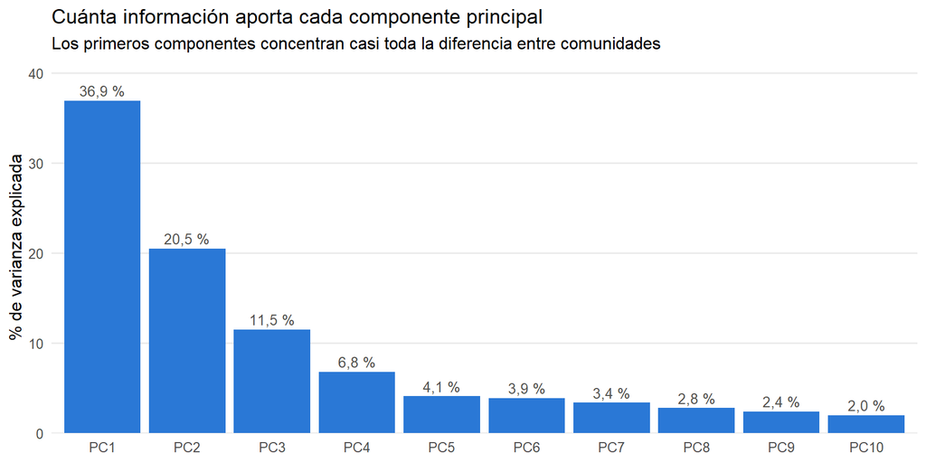

**Figura 11.** Porcentaje de la varianza explicada por cada uno de los diez primeros componentes principales.

**Tabla 6.** Varianza explicada por cada componente principal y varianza acumulada.

| Componente | % varianza | % acumulado |
| --- | --- | --- |
| PC1 | 36,9 | 36,9 |
| PC2 | 20,5 | 57,3 |
| PC3 | 11,5 | 68,8 |
| PC4 | 6,8 | 75,7 |
| PC5 | 4,1 | 79,8 |
| PC6 | 3,9 | 83,6 |
| PC7 | 3,4 | 87 |
| PC8 | 2,8 | 89,8 |
| PC9 | 2,4 | 92,2 |
| PC10 | 2 | 94,2 |

El resultado es contundente: los **dos primeros componentes explican ya el 57,3 %** de toda la variación entre las 17 comunidades, y con **6 componentes** se supera el 80 %. Dicho de otro modo: las diferencias entre comunidades autónomas españolas en calidad de vida, que parecían necesitar 67 indicadores para describirse, caben en la práctica en 6 ideas. Los 67 indicadores no son 67 fenómenos distintos.

## 6.3 ¿Qué significan esos ejes?

Un componente se interpreta mirando qué indicadores tienen más peso (“carga”) en él, y en qué sentido:

**Tabla 7.** Indicadores con más peso en cada extremo de los dos primeros componentes principales.

Los 6 indicadores con más peso en cada extremo de los dos primeros componentes

| Componente | Indicadores del extremo negativo | Indicadores del extremo positivo |
| --- | --- | --- |
| PC1 | Pobreza umbral fijo 2008; Pobreza relativa; Salarios bajos; Form. 25-64: nivel 0-2; Gastos imprevistos; Tasa de paro | Confianza en los demás; Esperanza de vida; Form. 25-64: nivel 5-8; PIB per cápita real; Renta mediana real; Renta media real |
| PC2 | Salud: mala; Morbilidad crónica; Jornada larga 49h+; Satisf. trabajo 5-6; Salud: regular; Limit. actividad: grave | Ruidos vecinos/exterior; Gasto elevado vivienda; Falta espacio vivienda; Jornada larga 40-48h; Salud: muy buena; Tasa de criminalidad |

**PC1 (36,9 % de la varianza) es un eje de nivel socioeconómico.** En un extremo se acumulan pobreza, salarios bajos, paro y población con estudios solo básicos; en el otro, renta alta, más PIB por habitante, estudios superiores y también más esperanza de vida y más confianza en los demás. Es, con diferencia, el factor que más separa a unas comunidades de otras: por sí solo explica más de un tercio de toda la variación. No es una sorpresa, pero es valioso que el dato lo confirme sin que nadie se lo haya sugerido al algoritmo.

**PC2 (20,5 %) es un eje de dinamismo demográfico.** En su extremo positivo se juntan buena salud percibida, mucha gente trabajando, jornadas de 40 a 48 horas… y también **gasto elevado en vivienda, falta de espacio, ruidos y criminalidad**. En el negativo, enfermedad crónica, mala salud percibida y menos empleo. No es un eje de “mejor o peor”: describe la diferencia entre comunidades jóvenes, que crecen y están bajo presión, y comunidades más envejecidas, tranquilas y baratas.

PC3 (11,5 %) no tiene una lectura tan limpia como los dos primeros: mezcla indicadores de contaminación, empleo y hábitos de salud. Illes Balears es la comunidad con el valor más alto (el Anexo D lo detalla).

**Cómo se sabe que PC2 va de crecimiento de la población.** Con un dato que el PCA no ha visto. La posición de cada comunidad en PC2 correlaciona **r = 0,88** con cuánto ha crecido su población entre 2000 y 2023, y ese crecimiento no es ninguno de los 82 indicadores. (La correlación, *r*, mide de −1 a +1 lo bien que dos cifras se mueven juntas; un valor así de cercano a 1 es muy alto.) En lo alto del eje están las comunidades que más han crecido: Illes Balears (+43 %, la que más), Madrid, Canarias, Cataluña, Murcia. En lo bajo, las que han crecido poco o han perdido población: Galicia, Castilla y León, Asturias, Cantabria y Extremadura. Por eso no se le llama “eje urbano”: País Vasco, muy urbano pero con una población que apenas ha crecido, queda en la mitad baja.

**Esto ya es un hallazgo.** Que el coste de la vivienda, la criminalidad y el dinamismo laboral aparezcan **en el mismo componente**, sin que nadie lo haya impuesto, indica que en España tienden a ir juntos: las comunidades que crecen y atraen población son también las que soportan más presión sobre la vivienda y más delitos por habitante. Illes Balears es la comunidad más extrema de este eje, y eso ayuda a entender que su problema de vivienda no es solo una anomalía local, sino en parte el precio de estar en la punta de un fenómeno que comparten otras comunidades.

**¿Y el precio de la vivienda? Sigue a los dos ejes a la vez.** El precio de compraventa correlaciona 0,53 con PC1 (nivel socioeconómico) y 0,67 con PC2 (dinamismo); el del alquiler, 0,54 y 0,62. Es decir: la vivienda es más cara donde se gana más **y** donde la población crece, las dos cosas a la vez y en proporción parecida. El PIB per cápita, en cambio, se alinea casi solo con el primer eje (0,90 frente a 0,36), como cabe esperar de una medida de riqueza.

Illes Balears ilustra bien esa doble dependencia: en el eje de nivel socioeconómico está en mitad de la tabla (puesto 8 de 17), pero en el de dinamismo es la primera de España. Por renta no le correspondería una vivienda especialmente cara; por dinamismo, la más cara. El precio real se parece mucho más a lo segundo. El modelo de vivienda del apartado 10 vuelve sobre esto y calcula qué parte del precio balear explican su renta y el crecimiento de su población.

## 6.4 Un indicador que pesa mucho en el primer eje: los estudios superiores de los adultos

**Tabla 8.** Los diez indicadores más ligados al eje de nivel socioeconómico (PC1) y puesto de Illes Balears en cada uno (medianas 2020–2024).

| Indicador | Correlación con PC1 | Illes Balears | España | Unidad | Puesto de Illes Balears |
| --- | --- | --- | --- | --- | --- |
| Pobreza umbral fijo 2008 | −0,96 | 15,3 | 20,5 | % | 6 |
| Pobreza relativa | −0,95 | 15,3 | 20,4 | % | 6 |
| Renta media real | 0,95 | 21.737,8 | 21.406,4 | Euros constantes de 2023 | 7 |
| Renta mediana real | 0,95 | 20.512,8 | 18.868,6 | Euros constantes de 2023 | 6 |
| PIB per cápita real | 0,9 | 33.550,2 | 29.862,3 | Euros constantes de 2023 por habitante | 6 |
| Salarios bajos | −0,89 | 10,5 | 16,5 | % | 3 |
| Form. 25-64: nivel 5-8 | 0,88 | 34,6 | 40,7 | % | 14 |
| Form. 25-64: nivel 0-2 | −0,87 | 38,3 | 36,3 | % | 11 |
| Gastos imprevistos | −0,87 | 36,3 | 35,5 | % | 11 |
| Tasa de paro | −0,86 | 10,6 | 13 | % | 8 |

Puesto entre las 17 comunidades: 1 = el valor más favorable (el más alto si que suba es bueno, el más bajo si es malo).  
Columna *Indicador*: verde = que suba es bueno; morado = que suba es malo; sin color = depende.

En los indicadores económicos del eje (pobreza, renta, PIB per cápita, salarios bajos, paro), Illes Balears está entre el puesto 3 y el 8 de 17. En formación superior de los adultos cae al **puesto 14**. Es la pieza de su perfil que más la separa de las comunidades con las que comparte grupo en el apartado 7.

**Dónde está hoy.** En 2020–2024, el 34,6 % de los baleares de 25 a 64 años tiene estudios superiores, frente al 40,7 % de España: **6,1 puntos menos**. Solo Murcia, Extremadura y Castilla-La Mancha tienen un porcentaje más bajo, y Andalucía y Canarias están prácticamente igual. La distancia con la primera, País Vasco, es de 20 puntos.

[interactive chart not shown]

**Figura 12.** Porcentaje de la población de 25 a 64 años con estudios superiores (CINE 5-8) por comunidad autónoma, mediana 2020–2024.

**Veinte años de evolución: la distancia se acortó y volvió a abrirse.** En 2004, Illes Balears era la **última** de las 17 comunidades (18,0 % frente a 26,7 %, una distancia de 8,7 puntos), y lo siguió siendo casi todos los años hasta 2011. Desde entonces el porcentaje de adultos con estudios superiores ha crecido mucho en las islas: **16,6 puntos** entre 2004 y 2024, algo más que en España (15,3), el 6.º mayor aumento de las 17. Pero como el resto de España también avanzaba, la distancia se redujo poco a poco y con altibajos: llegó a su mínimo en 2021 (4,1 puntos, puesto 12) y desde entonces ha vuelto a abrirse: en 2024 era de 7,4 puntos (puesto 15). En proporción sí se ve la mejora: en 2004 había 0,67 adultos con estudios superiores en Illes Balears por cada uno en España; en 2024, 0,82.

El mejor momento coincide con los años de la pandemia (2020 y 2021) y se deshace en 2022, cuando se recupera la actividad turística. Con estos datos no se puede saber si es un cambio real en quién vive en las islas o un vaivén de la encuesta, así que conviene no darle demasiado peso.

[interactive chart not shown]

**Figura 13.** Población de 25 a 64 años con estudios superiores, 2004–2024: Illes Balears, España y el resto de comunidades (en gris).

**Tabla 9.** Illes Balears frente a España en formación superior de 25 a 64 años, años seleccionados.

| Año | Illes Balears (%) | España (%) | Diferencia (puntos) | Por cada titulado en España | Puesto de Illes Balears |
| --- | --- | --- | --- | --- | --- |
| 2004 | 18 | 26,7 | −8,7 | 0,67 | 17 |
| 2008 | 20,8 | 29,5 | −8,7 | 0,71 | 17 |
| 2011 | 23,7 | 31,9 | −8,2 | 0,74 | 17 |
| 2014 | 27,9 | 34,7 | −6,8 | 0,8 | 12 |
| 2017 | 31,2 | 36,4 | −5,2 | 0,86 | 12 |
| 2019 | 31,9 | 38,6 | −6,7 | 0,83 | 13 |
| 2021 | 36,3 | 40,4 | −4,1 | 0,9 | 12 |
| 2024 | 34,6 | 42 | −7,4 | 0,82 | 15 |

**Por edades: el hueco no viene de las generaciones mayores.** El mismo indicador existe para otros dos grupos de edad, y el contraste es claro. Entre los mayores de 65 años, Illes Balears está cerca de la media (15,0 % frente a 16,5 %, puesto 10). La distancia aparece en la población en edad de trabajar y es todavía mayor, en proporción, entre los jóvenes de 18 a 24 años, donde es la última de España (aunque, como se dijo en el apartado 4, en ese grupo hay muchos que aún están estudiando).

**Tabla 10.** Población con estudios superiores por grupo de edad, y nivel de estudios de la población de 25 a 64 años (medianas 2020–2024).

| Indicador | Illes Balears (%) | España (%) | Diferencia (puntos) | Puesto de Illes Balears |
| --- | --- | --- | --- | --- |
| Estudios superiores, por edad |  |  |  |  |
| Form. 18-24: nivel 5-8 | 14,6 | 20,2 | −5,6 | 17 |
| Form. 25-64: nivel 5-8 | 34,6 | 40,7 | −6,1 | 14 |
| Form. 65+: nivel 5-8 | 15 | 16,5 | −1,5 | 10 |
| Adultos de 25 a 64 años, por nivel |  |  |  |  |
| Form. 25-64: nivel 0-2 | 38,3 | 36,3 | 2 | 11 |
| Form. 25-64: nivel 3-4 | 27,9 | 23 | 4,9 | 1 |
| Form. 25-64: nivel 5-8 | 34,6 | 40,7 | −6,1 | 14 |

Puesto entre las 17 comunidades: 1 = el valor más favorable. En el nivel 3-4 (bachillerato y FP de grado medio), cuya polaridad es «depende», el puesto 1 es el porcentaje más alto.  
Columna *Indicador*: verde = que suba es bueno; morado = que suba es malo; sin color = depende.

**¿Dónde se quedan los que no llegan a estudios superiores?** Sobre todo en el nivel intermedio, no en el básico. Entre los adultos de 25 a 64 años, Illes Balears tiene 6,1 puntos menos de estudios superiores que España, pero solo 2,0 más de estudios básicos y **4,9 más de bachillerato o FP de grado medio**, el porcentaje más alto de España. Es decir: el déficit balear no es tanto de población sin estudios como de población que se detiene un escalón antes de los estudios superiores.

**Lo que haría esperar su renta.** En las otras 16 comunidades, la formación superior de los adultos y la renta media van muy juntas (r = 0,94). Con la renta que tiene Illes Balears, esa relación haría esperar alrededor de un **42 %** de adultos con estudios superiores, el nivel de España; tiene un 34,6 %, 7 puntos menos. Visto al revés, Illes Balears consigue una renta intermedia con una formación de las más bajas. No es una relación de causa y efecto (puede leerse en los dos sentidos), pero encaja con lo que muestra el análisis de rutas del apartado 9: las islas tienen menos paro del que les correspondería por su nivel de formación.

**Qué significa.** La formación superior de los adultos es el rasgo más persistente de Illes Balears dentro del eje que más separa a las comunidades españolas. En los indicadores económicos de ese eje está en la mitad alta o en el centro de la tabla; en este, en el tercio inferior, junto a las comunidades de menor nivel socioeconómico. La distancia con España se ha reducido en proporción en veinte años, pero en puntos sigue casi donde estaba, y en los últimos tres años ha vuelto a abrirse.

El perfil es muy concreto: no faltan tanto estudios básicos como estudios superiores, y lo que sobra es el nivel intermedio. Eso casa con una economía básicamente de servicios que genera mucho empleo para el que basta el bachillerato o la FP de grado medio o trabajadores sin formación. Hay otra pieza que estos datos no permiten separar: el indicador mide a quien **reside** en las islas, y Illes Balears es la comunidad cuya población más ha crecido desde 2000 (+43 %). Si la distancia viene del sistema educativo de las islas o de quién llega a trabajar a ellas no se puede saber con estos indicadores; ambas explicaciones son plausibles, ninguna está demostrada.

# 7 ¿A qué se parece Illes Balears? Agrupación con k-means

## 7.1 Para qué sirve agrupar

El apartado 4 nos dice en qué es Illes Balears excepcional. Pero “excepcional respecto a la media” puede ser engañoso: si Illes Balears se parece mucho a Madrid y a Cataluña, y las tres se salen de la media en las mismas cosas, entonces no es una rareza — es un **tipo** de comunidad.

Para comprobarlo se usa **k-means**, un algoritmo de agrupación.

**Qué hace k-means.** Le pedimos que reparta las 17 comunidades en 3 grupos de forma que, dentro de cada grupo, las comunidades se parezcan lo máximo posible entre sí, y los grupos se diferencien lo máximo posible entre ellos.

Lo importante es que el algoritmo **no sabe nada** de geografía, de historia ni de política, y desde luego no sabe cuál de los puntos es Illes Balears. Solo ve números. Si aun así coloca a Illes Balears junto a determinadas comunidades, esa semejanza está de verdad en los datos.

El número de grupos, en cambio, sí lo decide quien hace el análisis. Aquí se le piden 3 porque con 17 comunidades da grupos de tamaño parecido y fáciles de describir. Es una decisión razonable, no la única: el Anexo D prueba con 4 grupos y con otro algoritmo de agrupación, y el reparto en 3 resiste bien.

Conviene no imaginar tres islas bien separadas. Las comunidades forman más bien una nube continua, y los grupos son zonas de esa nube: hay comunidades en el borde entre dos grupos que podrían haber caído en cualquiera de ellos.

**Sobre qué datos se agrupa.** No sobre los indicadores originales, sino sobre los **6 componentes principales** del apartado anterior (el 80 % de la información). Con solo 17 comunidades y 67 variables, agrupar directamente daría demasiado peso al ruido; usar los componentes principales concentra la señal y descarta el resto.

**Sobre la numeración de los grupos.** k-means los numera de forma arbitraria, así que aquí se han renumerado de mayor a menor nivel socioeconómico medio: el **Grupo 1 es siempre el de mayor nivel** y el 3 el de menor. El número, por tanto, significa algo y no cambia si el algoritmo se reinicia.

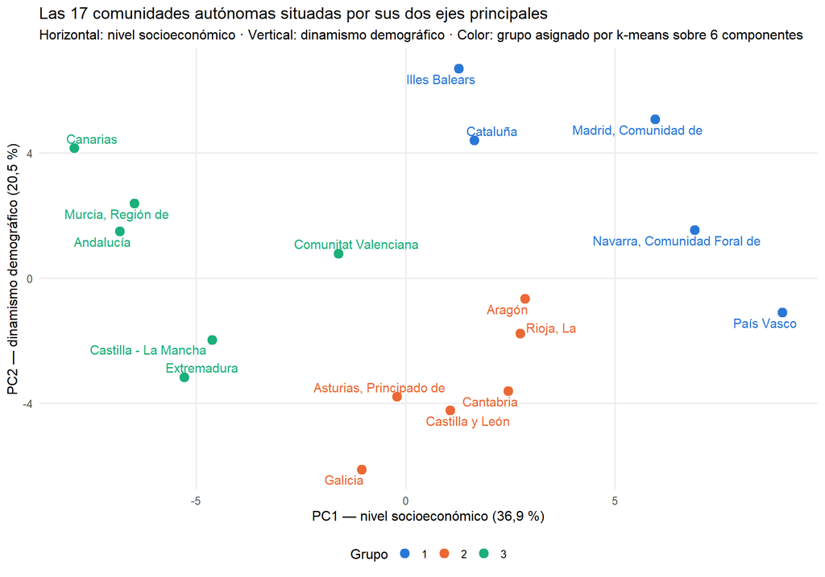

**Figura 14.** Las 17 comunidades autónomas en el plano de los dos primeros componentes principales, coloreadas según el grupo que les asigna k-means.

**Tabla 11.** Las 17 comunidades autónomas por grupo de k-means, con algunos indicadores de referencia (mediana de los últimos 5 años).

Los tres grupos y algunos indicadores de referencia

Mediana de los últimos 5 años disponibles

| CCAA | Grupo | Renta media real (€ de 2023) | PIB per cápita real (€ de 2023) | Paro (%) | Empleo (%) | Abandono educativo (%) | Salud muy buena (%) | Compra (€/m² de 2024) | Alquiler (€/m²/mes de 2024) | Criminalidad (por 1.000 hab.) |
| --- | --- | --- | --- | --- | --- | --- | --- | --- | --- | --- |
| Cataluña | 1 | 24.057 | 35.436 | 10 | 54,9 | 14,9 | 19,5 | 2.516 | 9,84 | 60,7 |
| Illes Balears | 1 | 21.738 | 33.550 | 10,6 | 57,1 | 18 | 21,8 | 3.271 | 9,37 | 63,4 |
| Madrid, Comunidad de | 1 | 25.712 | 41.591 | 11,2 | 56,2 | 10,5 | 19 | 3.211 | 12,12 | 56,5 |
| Navarra, Comunidad Foral de | 1 | 25.952 | 36.908 | 9,9 | 52,9 | 8,4 | 18,7 | 1.974 | 6,76 | 50 |
| País Vasco | 1 | 26.743 | 38.205 | 8,9 | 51,4 | 6,1 | 16,5 | 3.056 | 10,09 | 46 |
| Aragón | 2 | 22.495 | 34.244 | 9,6 | 53,1 | 12,5 | 17 | 1.582 | 7,1 | 35,9 |
| Asturias, Principado de | 2 | 21.707 | 27.318 | 12,4 | 44 | 10,5 | 14,5 | 1.387 | 6,62 | 31,9 |
| Cantabria | 2 | 21.481 | 27.852 | 9,6 | 49,5 | 7,3 | 14,8 | 1.768 | 7,22 | 40,4 |
| Castilla y León | 2 | 21.307 | 28.863 | 9,9 | 48,8 | 10,8 | 13,4 | 1.190 | 5,97 | 36,5 |
| Galicia | 2 | 19.841 | 27.638 | 11 | 47 | 9,9 | 9,9 | 1.504 | 5,77 | 35,1 |
| Rioja, La | 2 | 21.829 | 31.883 | 9,7 | 52,9 | 13,1 | 17 | 1.268 | 5,91 | 36,6 |
| Andalucía | 3 | 17.913 | 22.953 | 19,1 | 45,8 | 16,9 | 16,6 | 1.698 | 7,25 | 44,4 |
| Canarias | 3 | 17.886 | 23.591 | 17,6 | 48,7 | 13,1 | 16,4 | 2.251 | 7,62 | 43,4 |
| Castilla - La Mancha | 3 | 18.263 | 25.368 | 14,6 | 50,1 | 16,2 | 15 | 891 | 5,86 | 39,1 |
| Comunitat Valenciana | 3 | 19.414 | 26.671 | 13,3 | 50,9 | 15 | 21,2 | 1.526 | 5,99 | 51 |
| Extremadura | 3 | 16.684 | 22.924 | 17,4 | 45,4 | 13 | 16,7 | 822 | 4,99 | 30,4 |
| Murcia, Región de | 3 | 17.706 | 25.875 | 13,6 | 51,5 | 18,4 | 20 | 1.156 | 5,31 | 44,6 |

**Tabla 12.** Perfil medio de cada grupo de k-means.

Perfil medio de cada grupo

| Grupo | Nº CCAA | Renta media real (€ de 2023) | PIB per cápita real (€ de 2023) | Paro (%) | Empleo (%) | Abandono educativo (%) | Salud muy buena (%) | Compra (€/m² de 2024) | Alquiler (€/m²/mes de 2024) | Criminalidad (por 1.000 hab.) |
| --- | --- | --- | --- | --- | --- | --- | --- | --- | --- | --- |
| 1 | 5 | 24.840 | 37.138 | 10,1 | 54,5 | 11,6 | 19,1 | 2.806 | 9,64 | 55,3 |
| 2 | 6 | 21.443 | 29.633 | 10,4 | 49,2 | 10,7 | 14,4 | 1.450 | 6,43 | 36,1 |
| 3 | 6 | 17.978 | 24.564 | 15,9 | 48,7 | 15,4 | 17,6 | 1.391 | 6,17 | 42,1 |

## 7.2 Qué significa

El algoritmo encuentra tres perfiles muy reconocibles:

- **Grupo 1 — la España de mayor nivel socioeconómico (Illes Balears, Cataluña, Madrid, Navarra, País Vasco).** La renta media y el PIB por habitante más altos, la mejor tasa de empleo y la mejor salud percibida de los tres. Pero también, y esto es lo interesante, **la vivienda con diferencia más cara** (2.806 €/m² de 2024 de media, frente a unos 1.400 en los otros dos grupos: el doble) **y la criminalidad más alta**.
- **Grupo 2 — la España de nivel socioeconómico intermedio (Aragón, Asturias, Cantabria, Castilla y León, Galicia, La Rioja).** Renta intermedia y poco paro, pero una tasa de empleo baja, la peor salud percibida y la mayor proporción de enfermos crónicos de los tres: el perfil de poblaciones más envejecidas. Tiene el **menor abandono educativo** y una vivienda barata que, en relación con su renta, es la más asequible de los tres grupos.
- **Grupo 3 — la España de menor nivel socioeconómico (Andalucía, Canarias, Castilla-La Mancha, Comunitat Valenciana, Extremadura, Murcia).** La renta más baja, y con diferencia el mayor paro y el mayor abandono educativo. Su vivienda es la más barata en euros, aunque no en relación con lo que se gana.

**El hallazgo principal de este apartado.** Un algoritmo que no sabe qué es Illes Balears la coloca junto a Cataluña, Madrid, Navarra y País Vasco. Eso significa que buena parte del retrato del apartado 4 (mucho empleo, buena salud, vivienda cara y criminalidad alta) **no es una singularidad balear: es el perfil de la España de mayor nivel socioeconómico**.

Pero es un grupo con fronteras poco nítidas. Hay una medida para eso, el *coeficiente de silueta*, que vale 1 cuando una comunidad está claramente dentro de su grupo y 0 cuando está justo en la frontera con otro. La silueta media del Grupo 1 es 0,17, frente a 0,38 en el Grupo 2 y 0,17 en el 3: es, junto con el 3, el menos compacto. La de Illes Balears es 0,19, por debajo de la media de las 17 comunidades (0,24), y el grupo que le queda más cerca después del suyo es el Grupo 3 (la España de menor nivel socioeconómico). Y cuando se mira **dentro** del grupo, Illes Balears no es simplemente “el caso más acusado”: es el miembro descolgado.

**Tabla 13.** Illes Balears frente al resto del Grupo 1 (medianas 2020–2024).

|  | Illes Balears | Resto del Grupo 1 |
| --- | --- | --- |
| Renta media real (€ de 2023) | **21.738 €** (la más baja) | 24.057 – 26.743 € |
| PIB per cápita real (€ de 2023) | **33.550 €** (el más bajo) | 35.436 – 41.591 € |
| Precio de compraventa (€/m² de 2024) | **3.271 €/m²** (la más alta, casi empatada con Madrid) | 1.974 – 3.211 €/m² |
| Formación superior (25–64) | **34,6 %** (la más baja) | 43,6 – 55,0 % |

(Son medianas 2020–2024, que recogen el bache balear de la pandemia. Con el último dato, 2024, la distancia en renta se acorta, pero Illes Balears sigue siendo la de renta más baja del grupo: 23.689 € frente a 24.412–27.537 €.)

Sus cuatro pares combinan renta alta, PIB per cápita alto y nivel formativo alto, y eso les permite sostener precios altos. Illes Balears tiene los precios **sin** tener ninguna de las otras tres cosas, ni por “lo que gana cada hogar” ni por “lo que produce la economía”. Si hay que señalar un único rasgo genuinamente diferencial de las islas, más allá del déficit educativo, es **la combinación de precios de vivienda de comunidad rica con renta, producción económica y formación de comunidad media**.

La figura siguiente muestra el PIB per cápita real y la renta media real de cada comunidad, por grupo.

[interactive chart not shown]

**Figura 15.** PIB per cápita real (círculos) y renta media real (cuadrados) de cada comunidad autónoma, por grupo de k-means del apartado 7, en euros de 2023 (mediana de los últimos 5 años). Las líneas grises marcan la media de las 17 comunidades.

Finalmente, si se cruzan la renta (eje horizontal), la esperanza de vida (eje vertical) y el PIB per cápita (tamaño de los círculos), las comunidades se sitúan así:

[interactive chart not shown]

**Figura 16.** Renta media real (eje horizontal) y esperanza de vida (eje vertical) de cada comunidad autónoma, como diferencia con la media de las 17 (mediana de los últimos 5 años). El diámetro de los círculos crece con el PIB per cápita real; rellenos, las comunidades con PIB per cápita por encima de la media. Illes Balears, con borde naranja.

**Qué se ve.** Las dos figuras confirman el retrato del apartado: dentro del Grupo 1, Illes Balears es la comunidad con menos PIB per cápita y menos renta. Y frente al conjunto de España se queda en el centro: su renta está solo 518 € por encima de la media de las 17 y su esperanza de vida, 0,1 años por debajo, mientras sus cuatro compañeros de grupo están arriba a la derecha.

# 8 ¿Qué influye en qué? El análisis de rutas

Los apartados 3 a 7 describen en qué se diferencia Illes Balears del resto de España. Este apartado y los dos siguientes dan un paso más e intentan responder a **cómo se relacionan entre sí** esos indicadores: si la formación lleva al empleo, el empleo a la renta y la renta al bienestar; o si el precio de la vivienda depende de lo rica que es una comunidad o de cuánto crece su población. Y, sobre todo, **si Illes Balears sigue esas mismas reglas o se sale de ellas**.

## 8.1 De la correlación a las rutas

El PCA y los grupos de los apartados 6 y 7 se apoyan en **correlaciones**: dos indicadores están correlacionados cuando suelen subir y bajar juntos al pasar de una comunidad a otra. La correlación tiene un problema conocido: no dice *por qué* van juntos. Pueden ir juntos porque uno influye en el otro, porque los dos dependen de un tercero, o por una mezcla de las dos cosas.

Un **análisis de rutas** (*path analysis*, en inglés) es una forma de ordenar esas correlaciones. El analista dibuja primero un **diagrama de flechas** con lo que cree que influye en qué, y el análisis calcula:

- **cuánto pesa cada flecha**, descontando el efecto de las demás;
- **por qué caminos** llega la influencia de una variable a otra;
- y **si los datos son compatibles con el diagrama** o lo contradicen.

**Un ejemplo cotidiano: el precio de un coche de segunda mano.** La edad de un coche influye en su precio de dos maneras. Directamente (un coche más viejo es de un modelo más antiguo y vale menos) e indirectamente, a través de los kilómetros (un coche más viejo suele tener más kilómetros, y eso también lo abarata). Un diagrama de rutas lo dibujaría así:

**Edad → Precio** (efecto directo) y **Edad → Kilómetros → Precio** (efecto indirecto).

El análisis de rutas separa cuánto del efecto de la edad llega por cada camino. La suma de los dos es el **efecto total** de la edad sobre el precio.

## 8.2 Cómo se leen los números

Cada flecha lleva un número, el **coeficiente de ruta**. Se calcula poniendo todas las variables en la misma escala, en *desviaciones típicas* (la misma idea que el z-score del apartado 4), para poder comparar flechas entre variables que se miden en unidades distintas (euros, %, €/m²…). Se lee así:

**Un coeficiente de 0,70** en la flecha A → B significa: *si una comunidad estuviera una desviación típica por encima de otra en A, y en todo lo demás que llega a B fueran iguales, estaría 0,70 desviaciones típicas por encima en B*.

- **Signo**: positivo (azul) si A y B suben juntos; negativo (rojo) si cuando A sube B baja.
- **Tamaño**: cerca de 0, la flecha apenas pesa; cerca de 1 (o de −1), pesa mucho. Como guía: por debajo de 0,2 es un efecto pequeño, alrededor de 0,5 mediano, y por encima de 0,7 grande.

Dentro de cada caja que recibe flechas aparece además su **R²** (se lee “erre cuadrado”): el porcentaje de las diferencias entre comunidades en esa variable que explican las flechas que le llegan. Un R² de 0,90 quiere decir que, sabiendo las variables de las que parten esas flechas, se adivina el 90 % de las diferencias; el 10 % restante se debe a factores que no están en el diagrama.

**Efecto directo, indirecto y total.** El efecto directo de A sobre B es la flecha que va de A a B. Un efecto indirecto es el que va por una cadena de flechas (A → C → B), y vale el *producto* de los números de la cadena: si A → C vale 0,5 y C → B vale 0,6, el efecto de A sobre B a través de C es 0,5 × 0,6 = 0,30. El efecto total es la suma del directo y de todos los indirectos.

## 8.3 Por qué no basta con fiarse del diagrama

El diagrama lo decide el analista. Por eso el análisis incluye dos controles.

**Control 1: ¿cuánto nos podemos fiar de cada número? (bootstrap).** Con solo 17 comunidades, cada coeficiente depende mucho de qué comunidades haya. Para medirlo se usa el **bootstrap**: se sortean 17 comunidades *con reemplazo* (así en cada sorteo unas salen repetidas y otras no salen), se recalcula todo el modelo, y se repite 2.000 veces. Si el intervalo del 95 % de esos resultados no incluye el 0 (es decir, si el coeficiente tiene el mismo signo en al menos el 97,5 % de los sorteos), se considera que la flecha **se sostiene**; si el intervalo incluye el 0, la flecha puede no existir, y en los diagramas aparece **en gris y discontinua**.

**Por qué el bootstrap y no las fórmulas clásicas.** Las fórmulas clásicas para calcular estos intervalos suponen que hay muchos datos y que se reparten de una forma concreta (la “campana” o distribución normal). Con 17 comunidades esas suposiciones son dudosas. El bootstrap no las necesita: deja que sean los propios datos los que digan cuánto varía el resultado. Es especialmente útil para los efectos indirectos, que son productos de coeficientes y no siguen ninguna “campana”.

**Control 2: ¿los datos contradicen el diagrama? (las flechas que faltan).** Un diagrama no solo afirma lo que dibuja; también afirma lo que **no** dibuja. Si no hay flecha de la formación a la satisfacción vital, el diagrama está diciendo que *la formación influye en la satisfacción solo a través de otras variables*; dicho de otro modo, que conocidas esas otras variables, la formación no añade nada. Eso se puede comprobar con los datos. Se comprueba cada flecha ausente y se combinan los resultados en una única prueba global (la de Shipley, basada en el estadístico *C* de Fisher).

**Cómo se lee el resultado de esa prueba: el p-valor.** Es la probabilidad de ver unos datos tan “incómodos” para el diagrama como los que hay si el diagrama fuera correcto. Por convenio:

- **p-valor por encima de 0,05**: los datos **no contradicen** el diagrama. Es lo que se busca. Ojo: *no contradecir* no es lo mismo que *demostrar*; otros diagramas distintos podrían encajar igual de bien.
- **p-valor por debajo de 0,05**: los datos contradicen el diagrama; falta alguna flecha importante o sobra alguna hipótesis.

## 8.4 Lo que un análisis de rutas no puede hacer

- **No demuestra causas.** Calcula el peso de las flechas *suponiendo* que el diagrama es correcto. Si una flecha va en realidad en el sentido contrario, o si falta una causa común importante que no está en los datos, los números pueden engañar. Por eso cada flecha de los dos modelos se justifica con un razonamiento, no solo con los datos.
- **Con 17 comunidades, los modelos tienen que ser pequeños.** Cada flecha que llega a una variable “gasta” parte de la poca información que hay. Aquí ninguna variable recibe más de dos flechas.
- **Las comunidades no son personas.** Que las comunidades con más renta tengan más satisfacción vital no implica que dentro de cada comunidad las personas con más renta estén más satisfechas (aunque probablemente sea así). Confundir los dos niveles es un error clásico que tiene nombre: la **falacia ecológica**. Todas las conclusiones de este análisis, como las del resto del informe, son sobre comunidades.

## 8.5 Los datos de los dos modelos

Se usan exactamente los mismos datos que en el PCA y los grupos (apartados 6 y 7): para cada una de las 17 comunidades autónomas, la **mediana de los últimos cinco años disponibles** de cada indicador, que protege el resultado de un año atípico (ver el apartado 2).

De los 82 indicadores del informe se han escogido 9, más uno externo (el crecimiento de la población), para construir dos modelos con una pregunta clara cada uno. Con 17 comunidades no es posible meter muchos más en un mismo modelo (ver la sección anterior).

**Tabla 14.** Variables de los dos modelos de rutas.

| Variable | Modelo | Qué mide | Unidad | Illes Balears | Media del resto | Puesto de Illes Balears (de 17) |
| --- | --- | --- | --- | --- | --- | --- |
| Formación superior | 1 | Porcentaje de la población de 25 a 64 años con estudios superiores (FP de grado superior, universidad o doctorado). | % | 34,6 | 40,9 | 14 |
| Paro | 1 | Porcentaje de la población activa (la que trabaja o busca trabajo) que no tiene empleo. | % | 10,6 | 12,4 | 10 |
| Renta media real | 1 y 2 | Ingresos anuales medios de los hogares, ajustados por su tamaño y composición. Descontada la inflación (euros de 2023). | € de 2023 por unidad de consumo | 21.737,8 | 21.186,9 | 7 |
| Carencia material | 1 | Porcentaje de población que no puede permitirse al menos 3 cosas de una lista básica (una semana de vacaciones, calentar la casa, un gasto imprevisto, comer carne o pescado cada dos días...). | % | 16,0 | 15,9 | 8 |
| Confianza en los demás | 1 | Porcentaje de personas de 16 años o más que puntúa de 7 a 10 su confianza en los demás. | % | 53,9 | 52,2 | 6 |
| Satisfacción vital | 1 | Porcentaje de personas de 16 años o más que puntúa de 7 a 10 su satisfacción con la vida. | % | 73,5 | 72,1 | 6 |
| Crecimiento de población | 2 | Cuánto ha aumentado la población de la comunidad entre 2000 y 2023 (INE, cifras de población). | % 2000–2023 | 43,1 | 15,5 | 1 |
| Precio de la vivienda | 2 | Precio medio de compraventa de vivienda por metro cuadrado (Colegio de Registradores). Descontada la inflación (euros de 2024). | €/m² de 2024 | 3.271,3 | 1.737,5 | 1 |
| Gasto elevado en vivienda | 2 | Porcentaje de población que dedica más del 40 % de su renta disponible a los gastos de la vivienda. | % | 11,8 | 7,7 | 2 |
| Falta de espacio | 2 | Porcentaje de población que vive en una vivienda sin espacio suficiente (hacinamiento). | % | 9,7 | 5,9 | 2 |

Puesto 1 = valor más alto. Mediana de los últimos 5 años de cada indicador (crecimiento de la población: 2000-2023).

**Tres avisos sobre los datos.**

- **La renta y el precio de la vivienda aparecen con la inflación descontada**, como en el resto del informe: van en **euros constantes**, de 2023 la renta (cuyo último dato son ingresos de 2023) y de 2024 el precio (ver el apartado 2). Una renta o un precio más alto significa, por tanto, más poder de compra o una vivienda más cara de verdad, no solo más inflación.
- **La renta de Illes Balears está algo rebajada por la pandemia**, por lo que explica el apartado 4: con la mediana 2020–2024 queda en el **puesto 7** en renta media (en 2021 y 2022 cayó a los puestos 11 y 10), mientras que en los años normales suele estar entre el 5 y el 8. Se tiene en cuenta al interpretar los resultados de Illes Balears.
- **El crecimiento de la población no es un indicador del ICV.** Se ha tomado de la misma extracción del INE que el PIB per cápita (cifras de población de 2000 y 2023). Se incluye porque, como se vio en el apartado 6, es lo que mejor resume el segundo gran eje de diferencias entre comunidades (el “dinamismo demográfico”), y es una explicación natural del precio de la vivienda: donde llega más gente, hay más demanda de casas.

# 9 Modelo 1: de la formación al bienestar

## 9.1 La hipótesis

La pregunta es: **¿por qué caminos se relaciona el nivel de formación de una comunidad con la satisfacción vital de sus habitantes?** El diagrama propuesto sigue un razonamiento en cadena:

- **Formación → Paro (−).** Las personas con más estudios encuentran trabajo con más facilidad; una comunidad con más titulados debería tener menos paro.
- **Formación → Renta (+)** y **Paro → Renta (−).** Más estudios suelen suponer mejores sueldos, y menos paro supone más hogares con ingresos.
- **Paro → Carencia material (+)** y **Renta → Carencia material (−).** La carencia material (no poder permitirse cosas básicas) debería depender de cuánto se gana en promedio y, sobre todo, de cuántos hogares se quedan sin ingresos del trabajo.
- **Renta → Confianza en los demás (+).** Las sociedades más prósperas suelen ser también sociedades con más confianza social; es un resultado muy repetido en los estudios internacionales.
- **Confianza → Satisfacción vital (+)** y **Carencia material → Satisfacción vital (−).** Se espera que la gente esté más satisfecha con su vida cuando confía en quienes la rodean y cuando no le faltan cosas básicas.

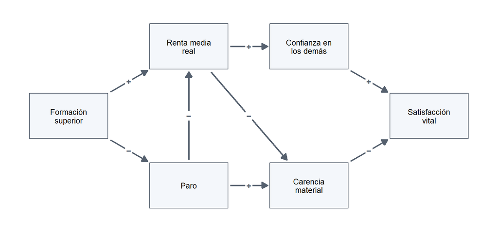

**Figura 17.** Modelo 1: diagrama de rutas de la hipótesis, con el signo esperado de cada flecha.

Y también importa lo que **no** se dibuja. Por ejemplo, no hay flecha directa de la formación a la satisfacción vital: el diagrama afirma que la formación solo influye en la satisfacción *a través* del empleo, la renta, la confianza y la carencia.

## 9.2 Lo que dicen los datos

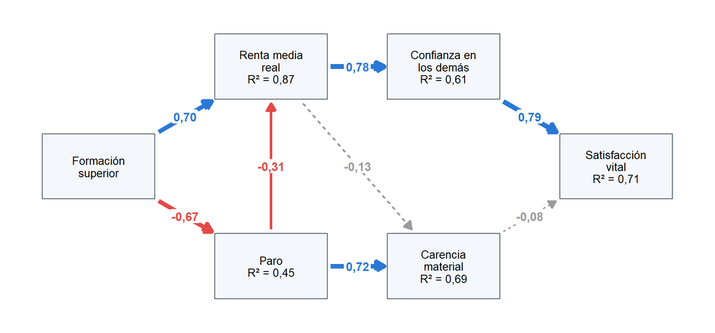

**Figura 18.** Modelo 1: diagrama de rutas con los coeficientes estimados.

**Cómo leer el diagrama.** Azul = efecto positivo; rojo = negativo; cuanto más gruesa la flecha, mayor el efecto. Las flechas **grises y discontinuas** son las que no se sostienen: en el bootstrap su valor cambia de signo con facilidad, así que podrían no existir. El R² de cada caja es la parte de sus diferencias entre comunidades que explican las flechas que le llegan.

**Tabla 15.** Modelo 1: coeficiente de cada flecha e intervalo del 95 %.

Modelo 1: el peso de cada flecha

Coeficientes estandarizados. Intervalo del 95 % por bootstrap (2.000 repeticiones)

| Flecha | Coeficiente | Intervalo del 95 % | ¿Se sostiene? |
| --- | --- | --- | --- |
| Formación superior → Paro | −0,67 | [-0,82 ; -0,49] | Sí |
| Formación superior → Renta media real | 0,70 | [0,41 ; 0,88] | Sí |
| Paro → Renta media real | −0,31 | [-0,58 ; -0,07] | Sí |
| Renta media real → Carencia material | −0,13 | [-0,54 ; 0,36] | No está claro |
| Paro → Carencia material | 0,72 | [0,29 ; 1,07] | Sí |
| Renta media real → Confianza en los demás | 0,78 | [0,50 ; 0,92] | Sí |
| Confianza en los demás → Satisfacción vital | 0,79 | [0,52 ; 1,05] | Sí |
| Carencia material → Satisfacción vital | −0,08 | [-0,38 ; 0,27] | No está claro |

Lo más destacado:

- **La cadena formación → paro → renta se ve con claridad.** La formación tiene un efecto grande sobre el paro (-0,67) y sobre la renta (0,70), y el paro añade un efecto propio sobre la renta (-0,31). Entre las dos variables explican el 87 % de las diferencias de renta entre comunidades: un valor altísimo.
- **La carencia material depende del paro, no de la renta media.** Una vez que se sabe cuánto paro hay, la renta media ya casi no añade nada (-0,13, con un intervalo entre -0,54 y 0,36, que incluye el 0). Tiene sentido: la renta *media* puede ser alta aunque una parte de los hogares no tenga ingresos; lo que empuja a la carencia es quedarse sin trabajo.
- **La satisfacción vital va de la mano de la confianza en los demás** (0,79), y la confianza, de la renta (0,78). En cambio, **la carencia material no añade nada** para predecir la satisfacción una vez conocida la confianza (-0,08, intervalo entre -0,38 y 0,27). A simple vista la carencia sí está relacionada con la satisfacción (correlación de -0,54), pero esa relación se explica porque las comunidades con más carencia son también las de menos renta y menos confianza.

## 9.3 ¿Encaja el diagrama con los datos?

El diagrama tiene 7 flechas ausentes, es decir, 7 afirmaciones comprobables. Esta tabla las recoge todas:

**Tabla 16.** Modelo 1: contraste de las flechas que el diagrama no dibuja (test de separación).

Modelo 1: las afirmaciones que hace el diagrama con las flechas que no dibuja

| Afirmación que hace el modelo (flecha ausente) | p-valor | ¿Los datos la contradicen? |
| --- | --- | --- |
| Conocidos renta media real, paro, formación superior no aporta nada para predecir carencia material | 0,54 | No |
| Conocidos renta media real, formación superior no aporta nada para predecir confianza en los demás | 0,31 | No |
| Conocidos confianza en los demás, carencia material, formación superior no aporta nada para predecir satisfacción vital | 0,50 | No |
| Conocidos formación superior, renta media real, paro no aporta nada para predecir confianza en los demás | 0,77 | No |
| Conocidos formación superior, confianza en los demás, carencia material, paro no aporta nada para predecir satisfacción vital | 0,64 | No |
| Conocidos formación superior, paro, confianza en los demás, carencia material, renta media real no aporta nada para predecir satisfacción vital | 0,40 | No |
| Conocidos renta media real, paro, carencia material no aporta nada para predecir confianza en los demás | 0,57 | No |

La prueba global da un **p-valor de 0,81** (*C* = 9,3 con 14 grados de libertad). Como es mayor que 0,05, **los datos no contradicen el diagrama**: ninguna de las flechas que se han dejado fuera parece necesaria.

## 9.4 Los caminos de la influencia

La tabla siguiente separa, para algunas parejas de variables, cuánto de la relación va por el camino directo y cuánto por caminos indirectos. La primera columna es la **correlación simple**, la que se vería sin ningún modelo; la última, el intervalo del 95 % del efecto total según el bootstrap.

**Tabla 17.** Modelo 1: efectos directos, indirectos y totales.

Modelo 1: efectos directos, indirectos y totales

| Relación | Correlación simple | Directo | Indirecto | Total | Intervalo del total |
| --- | --- | --- | --- | --- | --- |
| Formación superior → Renta media real | 0,91 | 0,70 | 0,21 | 0,91 | [0,76 ; 0,97] |
| Formación superior → Carencia material | −0,64 | 0,00 | −0,60 | −0,60 | [-0,81 ; -0,30] |
| Formación superior → Satisfacción vital | 0,48 | 0,00 | 0,61 | 0,61 | [0,29 ; 0,80] |
| Paro → Satisfacción vital | −0,48 | 0,00 | −0,25 | −0,25 | [-0,48 ; 0,02] |
| Renta media real → Satisfacción vital | 0,66 | 0,00 | 0,63 | 0,63 | [0,29 ; 0,92] |
| Carencia material → Satisfacción vital | −0,54 | −0,08 | 0,00 | −0,08 | [-0,38 ; 0,27] |

**Qué significa.**

- **La formación influye en la satisfacción vital, pero solo por caminos indirectos.** Su efecto total es de 0,61, y llega casi todo (más del 90 %) a través de la renta y la confianza. Es un buen ejemplo de lo que aporta el análisis de rutas: la correlación simple (0,48) dice que las dos cosas van juntas; el modelo dice *por dónde* podría llegar la influencia.
- **La formación también influye en la renta por dos caminos**: el directo (0,70, mejores sueldos) y el indirecto a través de un menor paro (0,21). El directo es con mucho el más importante.
- **El paro pesa en la satisfacción menos de lo que parece.** Su correlación simple con la satisfacción es de -0,48, pero su efecto total según el modelo es de -0,25: una parte de la correlación simple se debe a que las comunidades con más paro son también las de menos formación.

**Una advertencia sobre la flecha de la confianza a la satisfacción.** Es la flecha más fuerte del modelo, y también la más discutible. Las dos preguntas salen de la **misma encuesta**, y una persona optimista puede puntuar alto las dos cosas; además, podría haber una causa común que el modelo no ve (rasgos culturales o de cohesión social propios de cada territorio). Y el sentido de la flecha podría ser el contrario: las personas satisfechas con su vida pueden confiar más en los demás. Los datos no permiten distinguir entre estas explicaciones. Lo que sí dicen es que, entre comunidades, la renta se relaciona con la satisfacción vital **en la misma medida en que se relaciona con la confianza**, y no por otro camino.

## 9.5 Illes Balears en el modelo 1

¿Sigue Illes Balears las reglas que siguen las demás comunidades? Para responderlo, se estima cada flecha **con las otras 16 comunidades, sin Illes Balears**, y se calcula qué valor le correspondería a Illes Balears según sus causas directas. Por ejemplo, para el paro: qué paro tienen, en promedio, las comunidades con el mismo porcentaje de titulados superiores que Illes Balears.

El **rango normal** es el intervalo en el que caería el 95 % de las comunidades según el modelo: si Illes Balears queda dentro, se comporta como una comunidad más; si queda fuera, algo que no está en el modelo la distingue.

**Tabla 18.** Modelo 1: valores de Illes Balears frente a los que predicen las otras 16 comunidades.

Illes Balears frente a lo que predicen las otras 16 comunidades (modelo 1)

Cada fila usa los valores reales de Illes Balears en las causas directas de esa variable

| Variable | Unidad | Observado | Esperado | Rango normal (95 %) | Diferencia | ¿Fuera de lo normal? |
| --- | --- | --- | --- | --- | --- | --- |
| Paro | % | 10,6 | 14,6 | 9,3 – 19,9 | −4,0 (−27 %) | No |
| Renta media real | € de 2023 por unidad de consumo | 21.738 | 19.216 | 16.594 – 21.838 | +2.521 (+13 %) | No |
| Carencia material | % | 16,0 | 13,7 | 6,7 – 20,7 | +2,3 (+17 %) | No |
| Confianza en los demás | % | 53,9 | 52,7 | 47,7 – 57,7 | +1,1 (+2 %) | No |
| Satisfacción vital | % | 73,5 | 73,2 | 69,1 – 77,2 | +0,3 (+0 %) | No |

**Illes Balears sigue las reglas del bienestar, con una particularidad en el empleo.**

- **Tiene menos paro del que le correspondería por su formación**: 10,6 % frente a un esperado de 14,6 %. La diferencia no llega a salirse del rango normal, pero es la mayor de la tabla en términos relativos, y es coherente con lo que se sabe de su economía: el turismo y la construcción generan mucho empleo que no requiere estudios superiores. Illes Balears tiene pocos titulados (puesto 14 de 17) y, sin embargo, poco paro.
- **Y tiene más renta de la esperada** (21.738 € de 2023 frente a 19.216 €), lo mismo: una economía que, con poca formación superior, consigue rentas intermedias. Esto ocurre incluso con la renta rebajada por la pandemia (ver los avisos sobre los datos, en el apartado 8).
- **En confianza, carencia y satisfacción vital, Illes Balears queda dentro del rango normal.** Las piezas de su bienestar encajan con las del resto de España.

# 10 Modelo 2: la vivienda

## 10.1 La hipótesis

Los apartados 4 y 5 encontraron que Illes Balears tiene la vivienda más cara de España (a la par con Madrid), la que más se ha encarecido, y a la vez un porcentaje de población con gasto elevado en vivienda que baja; y el apartado 6, que el precio de la vivienda sigue a la vez al nivel de renta y al dinamismo demográfico. Este modelo intenta ordenar esas piezas:

- **Renta → Precio (+).** Donde se gana más, se puede pagar más por una casa, y los precios suben.
- **Crecimiento de la población → Precio (+).** Donde llega más gente, hay más demanda de vivienda, y si la oferta no crece al mismo ritmo, el precio sube.
- **Precio → Gasto elevado en vivienda (+).** Cuanto más cara la vivienda, más hogares dedican una parte excesiva de su renta a pagarla.
- **Renta → Gasto elevado en vivienda (−).** A igualdad de precios, donde se gana más, la vivienda pesa menos en el presupuesto.
- **Gasto elevado → Falta de espacio (+).** Cuando la vivienda cuesta demasiado, los hogares se aprietan: se alquilan pisos más pequeños o se comparten.

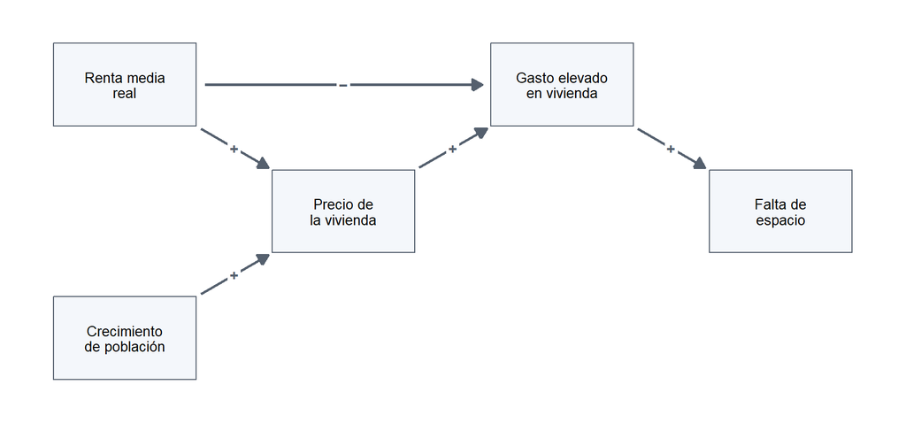

**Figura 19.** Modelo 2: diagrama de rutas de la hipótesis, con el signo esperado de cada flecha.

## 10.2 Lo que dicen los datos

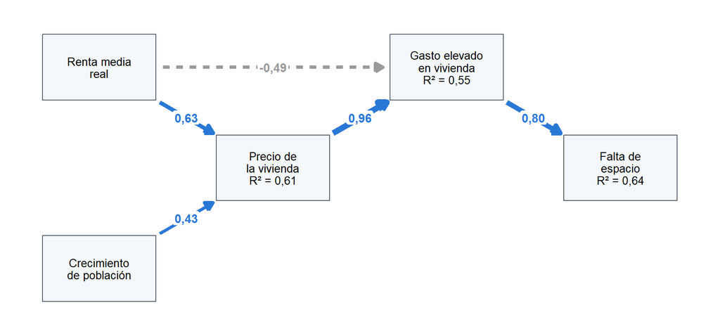

**Figura 20.** Modelo 2: diagrama de rutas con los coeficientes estimados.

**Tabla 19.** Modelo 2: coeficiente de cada flecha e intervalo del 95 %.

Modelo 2: el peso de cada flecha

Coeficientes estandarizados. Intervalo del 95 % por bootstrap (2.000 repeticiones)

| Flecha | Coeficiente | Intervalo del 95 % | ¿Se sostiene? |
| --- | --- | --- | --- |
| Renta media real → Precio de la vivienda | 0,63 | [0,26 ; 0,91] | Sí |
| Crecimiento de población → Precio de la vivienda | 0,43 | [0,07 ; 0,74] | Sí |
| Precio de la vivienda → Gasto elevado en vivienda | 0,96 | [0,46 ; 1,27] | Sí |
| Renta media real → Gasto elevado en vivienda | −0,49 | [-0,90 ; 0,12] | No está claro |
| Gasto elevado en vivienda → Falta de espacio | 0,80 | [0,44 ; 0,93] | Sí |

- **El precio depende de la renta (0,63) y del crecimiento de la población (0,43).** Las dos cosas juntas explican el 61 % de las diferencias de precio entre comunidades. La renta y el crecimiento de la población apenas están relacionados entre sí (correlación de 0,05), así que son dos motores distintos del precio, como ya anticipaba el PCA: la renta media correlaciona 0,95 con su primer eje, y el crecimiento de la población, 0,88 con el segundo, que es independiente del primero.
- **El precio es, con diferencia, lo que más empuja el gasto elevado en vivienda** (0,96), y el gasto elevado, a su vez, la falta de espacio (0,80).
- **La renta, a igualdad de precio, reduce el gasto elevado** (-0,49). Es la flecha menos segura del modelo: su intervalo va entre -0,90 y 0,12, así que incluye el 0 y no se puede descartar que no exista. Con 17 comunidades no hay información suficiente para afirmarlo con seguridad, aunque el signo es el que se esperaba y el valor, de tamaño mediano.

## 10.3 ¿Encaja el diagrama con los datos?

**Tabla 20.** Modelo 2: contraste de las flechas que el diagrama no dibuja (test de separación).

Modelo 2: las afirmaciones que hace el diagrama con las flechas que no dibuja

| Afirmación que hace el modelo (flecha ausente) | p-valor | ¿Los datos la contradicen? |
| --- | --- | --- |
| renta media real no aporta nada para predecir crecimiento de población | 0,85 | No |
| Conocidos gasto elevado en vivienda, renta media real no aporta nada para predecir falta de espacio | 0,59 | No |
| Conocidos precio de la vivienda, renta media real, crecimiento de población no aporta nada para predecir gasto elevado en vivienda | 0,47 | No |
| Conocidos gasto elevado en vivienda, crecimiento de población no aporta nada para predecir falta de espacio | 0,09 | No |
| Conocidos renta media real, crecimiento de población, gasto elevado en vivienda, precio de la vivienda no aporta nada para predecir falta de espacio | 0,33 | No |

La prueba global da un **p-valor de 0,45** (*C* = 9,9 con 10 grados de libertad). Los datos **no contradicen el diagrama**. La afirmación que más cerca está de rechazarse es la de que el crecimiento de la población solo influye en la falta de espacio a través del precio y del gasto (p-valor de 0,09): no llega a rechazarse, pero sugiere que la llegada de población podría apretar las viviendas también por otras vías (por ejemplo, porque los recién llegados comparten piso), que el modelo no recoge.

## 10.4 Dos efectos que se compensan

Este modelo ilustra muy bien una de las cosas que el análisis de rutas puede hacer y la correlación no.

**Tabla 21.** Modelo 2: efectos directos, indirectos y totales.

Modelo 2: efectos directos, indirectos y totales

| Relación | Correlación simple | Directo | Indirecto | Total | Intervalo del total |
| --- | --- | --- | --- | --- | --- |
| Renta media real → Gasto elevado en vivienda | 0,14 | −0,49 | 0,61 | 0,12 | [-0,30 ; 0,58] |
| Crecimiento de población → Gasto elevado en vivienda | 0,53 | 0,00 | 0,42 | 0,42 | [0,03 ; 0,71] |
| Precio de la vivienda → Falta de espacio | 0,58 | 0,00 | 0,77 | 0,77 | [0,20 ; 1,12] |
| Crecimiento de población → Falta de espacio | 0,65 | 0,00 | 0,33 | 0,33 | [0,02 ; 0,62] |
| Renta media real → Falta de espacio | 0,02 | 0,00 | 0,09 | 0,09 | [-0,25 ; 0,43] |

**La renta tiene dos efectos opuestos sobre el esfuerzo en vivienda, y en buena parte se anulan.** A simple vista, la renta de una comunidad y su porcentaje de población con gasto elevado en vivienda apenas tienen que ver (correlación de 0,14). Pero el modelo muestra que no es que no haya relación, sino que hay **dos relaciones que tiran en sentidos contrarios**:

- **Por el camino indirecto**, más renta → vivienda más cara → más gasto elevado: 0,61.
- **Por el camino directo**, más renta → más capacidad de pago → menos gasto elevado: -0,49.
- **El total** es 0,12: mucho menos que cualquiera de los dos caminos por separado.

Traducido: **las comunidades ricas no se libran del problema de la vivienda**, porque su propia riqueza encarece las casas y se “come” buena parte de la ventaja de ganar más. Este fenómeno, en el que un efecto oculta a otro, se llama en estadística **supresión**, y es la razón por la que una correlación cercana a cero no demuestra que dos cosas no estén relacionadas.

Con una salvedad: la flecha directa (renta → menos gasto elevado) es la menos segura del modelo, porque su intervalo incluye el 0. El camino indirecto, en cambio, sí se sostiene (intervalo del 95 % entre 0,16 y 1,03). Lo sólido es, por tanto, que la renta encarece la vivienda y que eso empuja el esfuerzo; que la mayor capacidad de pago lo compense en buena parte es lo más probable según los datos, pero no es seguro.

**El crecimiento de la población, en cambio, solo tiene un camino, y es de subida**: más población → más precio → más gasto elevado → más falta de espacio. Su efecto total sobre el gasto elevado es de 0,42 y sobre la falta de espacio, de 0,33.

## 10.5 Illes Balears en el modelo 2

**Tabla 22.** Modelo 2: valores de Illes Balears frente a los que predicen las otras 16 comunidades.

Illes Balears frente a lo que predicen las otras 16 comunidades (modelo 2)

Cada fila usa los valores reales de Illes Balears en las causas directas de esa variable

| Variable | Unidad | Observado | Esperado | Rango normal (95 %) | Diferencia | ¿Fuera de lo normal? |
| --- | --- | --- | --- | --- | --- | --- |
| Precio de la vivienda | €/m² de 2024 | 3.271 | 2.246 | 1.052 – 3.439 | +1.026 (+46 %) | No |
| Gasto elevado en vivienda | % | 11,8 | 12,5 | 7,4 – 17,7 | −0,7 (−6 %) | No |
| Falta de espacio | % | 9,7 | 11,1 | 5,2 – 16,9 | −1,4 (−12 %) | No |

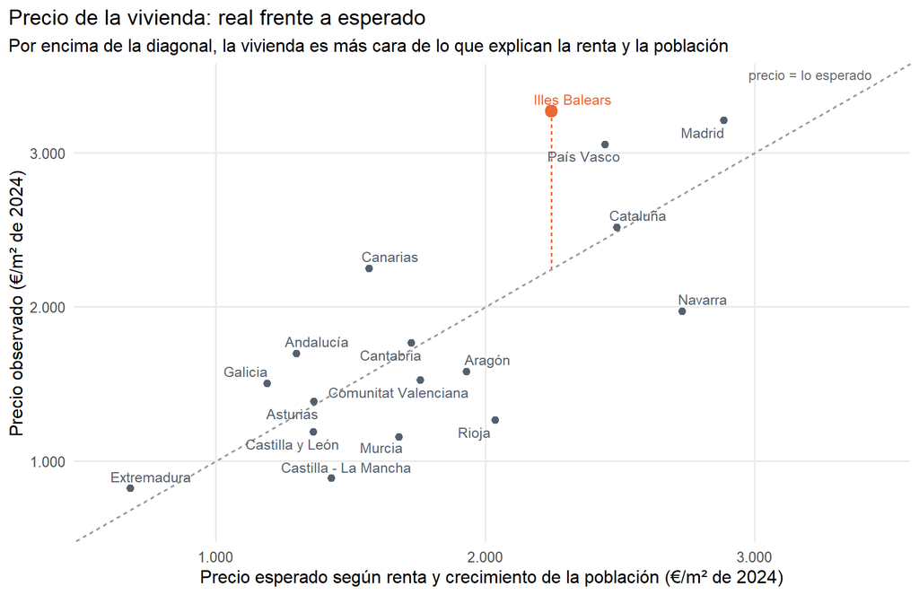

**Figura 21.** Precio de compraventa de vivienda observado frente al esperado según la renta y el crecimiento de la población de cada comunidad (€/m² de 2024).

**En el precio de la vivienda, Illes Balears se aparta mucho de la regla.**

**Illes Balears pesa mucho en una de las flechas.** Illes Balears es a la vez la comunidad cuya población más ha crecido desde 2000 (+43 %) y, con Madrid, la de la vivienda más cara. Eso la convierte en un caso muy influyente para la flecha *crecimiento de la población → precio*: si se quita Illes Balears del cálculo, su coeficiente baja de 0,43 a 0,29 y deja de ser claramente distinto de cero (p-valor de 0,12). Es decir: la relación entre llegada de población y precio se apoya en buena medida en el propio caso balear. Por eso la predicción para Illes Balears de la tabla anterior, calculada sin ella, le atribuye un precio esperado bastante más bajo. El Anexo E repite esta comprobación con todas las comunidades y todas las flechas.

# 11 Conclusiones

## 11.1 El retrato de Illes Balears

Juntando los cuatro ángulos de los apartados 4 a 7, el retrato que sale es coherente y tiene cuatro capas.

**1. Illes Balears vive bien en lo que no se compra.** La mejor tasa de empleo de España, la mejor salud autopercibida y la menor enfermedad crónica. No son datos de un año bueno: se mantienen tomando la mediana de un lustro (a ellos se suma la mayor satisfacción media con el trabajo, aunque de esta solo hay un año reciente, 2023), y el análisis multivariante confirma que colocan a Illes Balears en el grupo de mayor nivel socioeconómico del país. Con una cautela: parte de esa ventaja se debe probablemente a que su población es más joven, porque la esperanza de vida, que no depende de la edad de la población, está en la media.

**2. Pero su renta no está a la altura de su vivienda.** Su renta media por unidad de consumo, descontada la inflación, está en la zona media de España: casi siempre entre los puestos 5 y 8 en años normales (solo en 2018 entre las cuatro primeras) y puesto 7 con la mediana 2020–2024, que recoge el bache de la pandemia. Lo mismo pasa hoy con lo que produce su economía por habitante, algo por encima de la media sin llegar a las primeras posiciones (en 2000 era la segunda de España; el punto 3 explica por qué ya no). Mucho empleo no se ha traducido en renta alta, algo que encaja con un mercado laboral intensivo en servicios y con uno de los mayores abandonos escolares de España, aunque estos datos no permiten demostrar esa relación (el análisis de rutas encuentra algo compatible con ella: ver la conclusión 5).

**4. El déficit educativo persiste, aunque se ha acortado.** Con uno de los mayores abandonos escolares de España y la menor proporción de jóvenes con estudios superiores, las islas combinan un mercado laboral que absorbe rápido con un sistema que retiene poco. La buena noticia es que la formación superior en jóvenes es el indicador educativo que **más rápido crece** en Illes Balears: la distancia con el resto se ha reducido a menos de la mitad en veinte años. La mala, que el abandono escolar ha vuelto a subir desde 2021.

Una advertencia final que solo aparece al mirar las tendencias: hay señales de deterioro en la vida cotidiana, sobre todo un **hacinamiento que sube** más deprisa que en el resto del país. Son señales más débiles que las anteriores, pero son justo el tipo de cambio que una fotografía anual no detecta, y encajan con una presión creciente sobre la vivienda.

## 11.2 Lo que añade el análisis de rutas

**5. Hay una cadena clara que va de la formación al bienestar, y Illes Balears la sigue.** En España, las comunidades con más titulados superiores tienen menos paro y más renta; la renta va de la mano de la confianza en los demás, y la confianza, de la satisfacción vital. Illes Balears ocupa en esa cadena el lugar que le corresponde, salvo en un punto: tiene **menos paro del que haría esperar su bajo nivel de formación**. Su economía genera empleo sin necesitar titulados, lo que la protege del paro pero no la empuja a las rentas más altas. Es la otra cara del déficit educativo de la conclusión 4.

**6. La carencia material depende del paro más que de la renta media.** Una comunidad con una renta media aceptable puede tener mucha carencia si una parte de su población se queda sin trabajo. Para reducir la carencia, el indicador clave es el paro.

**7. La vivienda tiene dos motores, la renta y la llegada de población, y la riqueza no protege del problema.** La renta de una comunidad encarece sus casas a la vez que le da capacidad para pagarlas, y los dos efectos se compensan en buena parte. Coincide con lo que sugería el PCA (conclusión 3): el precio sigue a la vez a la renta y al dinamismo demográfico.

# Anexo A · Glosario

## Términos estadísticos

**Tabla 23.** Glosario de términos estadísticos.

[output not shown]

## Indicadores y fuentes

**Tabla 24.** Glosario de indicadores y fuentes.

[output not shown]

## Análisis de rutas

**Tabla 25.** Glosario del análisis de rutas.

[output not shown]

# Anexo B · Nombres de los indicadores

Los gráficos y tablas usan nombres abreviados para que quepan como etiqueta. Esta es la correspondencia completa con el nombre oficial, el organismo del que procede cada indicador y si es una buena o una mala noticia que suba (columna *Si sube*, con el mismo color que la columna *Indicador* de las tablas de los apartados 4 y 5):

**Tabla 26.** Nombre completo, nombre abreviado, fuente y polaridad de cada indicador.

Los 82 indicadores analizados, por dimensión

| Nombre abreviado | Nombre oficial | Unidad | Si sube | Fuente |
| --- | --- | --- | --- | --- |
| Condiciones materiales de vida |  |  |  |  |
| Carencia material | Carencia material - Carencia material (carencia en al menos 3 conceptos) | % | Malo | INE |
| Carencia material severa | Carencia material - Carencia material severa (carencia en al menos 4 conceptos) | % | Malo | INE |
| Deficiencias en vivienda | Población que vive en hogares con determinadas deficiencias en la vivienda | % | Malo | INE |
| Desigualdad S80/S20 | Desigualdad (S80/S20) | Veces (cociente) | Malo | INE |
| Falta espacio vivienda | Población con falta de espacio en la vivienda | % | Malo | INE |
| Fin mes: cierta dificultad | Dificultades para llegar a fin de mes - Con cierta dificultad | % | Malo | INE |
| Fin mes: dificultad | Dificultades para llegar a fin de mes - Con dificultad | % | Malo | INE |
| Fin mes: mucha dificultad | Dificultades para llegar a fin de mes - Con mucha dificultad | % | Malo | INE |
| Gasto elevado vivienda | Población con gasto elevado en vivienda | % | Malo | INE |
| Gastos imprevistos | Incapacidad de hacer frente a gastos económicos imprevistos | % | Malo | INE |
| PIB per cápita real | PIB per cápita real (precios constantes de 2023) | Euros constantes de 2023 por habitante | Bueno | PIB_CCAA |
| Pobreza relativa | Población en riesgo de pobreza relativa según distintos umbrales | % | Malo | INE |
| Pobreza umbral fijo 2008 | Población en riesgo de pobreza con umbral fijo en el año 2008 | % | Malo | INE |
| Precio alquiler (€/m²/mes) | Precio de alquiler de vivienda (euros constantes de 2024) | Euros constantes de 2024 por metro cuadrado al mes | Malo | SERPAVI |
| Precio compraventa (€/m²) | Precio de compraventa de vivienda (euros constantes de 2024) | Euros constantes de 2024 por metro cuadrado | Malo | REGISTRADORES |
| Renta media real | Renta media y mediana - Renta media por unidad de consumo (euros constantes de 2023) | Euros constantes de 2023 | Bueno | INE |
| Renta mediana real | Renta media y mediana - Renta mediana por unidad de consumo (euros constantes de 2023) | Euros constantes de 2023 | Bueno | INE |
| Retrasos en pagos | Retrasos en los pagos | % | Malo | INE |
| Satisf. vivienda: algo insat. | Satisfacción con la vivienda - Algo insatisfecho | % | Malo | INE |
| Satisf. vivienda: muy insat. | Satisfacción con la vivienda - Muy insatisfecho | % | Malo | INE |
| Satisf. vivienda: muy satisf. | Satisfacción con la vivienda - Muy satisfecho | % | Bueno | INE |
| Satisf. vivienda: satisfecho | Satisfacción con la vivienda - Satisfecho | % | Bueno | INE |
| Educación |  |  |  |  |
| Abandono educativo 18-24 | Abandono temprano de la educación-formación en la población de 18 a 24 años | % | Malo | INE |
| Form. 18-24: nivel 0-2 | Nivel de formación alcanzado por la población joven (de 18 a 24 años) - Nivel (0-2): preescolar, primaria y secundaria de 1ª etapa | % | Malo | INE |
| Form. 18-24: nivel 3-4 | Nivel de formación alcanzado por la población joven (de 18 a 24 años) - Nivel (3-4): secundaria de 2ª etapa y postsecundaria no superior | % | Depende | INE |
| Form. 18-24: nivel 3-8 | Nivel de formación alcanzado por la población joven (de 18 a 24 años) - Nivel (3-8): Educación secudaria o superior | % | Bueno | INE |
| Form. 18-24: nivel 5-8 | Nivel de formación alcanzado por la población joven (de 18 a 24 años) - Nivel (5-8): primer y segundo ciclo de educación superior y doctorado | % | Bueno | INE |
| Form. 25-64: nivel 0-2 | Nivel de formación alcanzado por la población adulta - De 25 a 64 años - Nivel (0-2): preescolar, primaria y secundaria de 1ª etapa | % | Malo | INE |

[output cut: 60 more lines]

Columna *Nombre abreviado*: verde = que suba es bueno; morado = que suba es malo; sin color = depende.

# Anexo C · Datos y reproducibilidad

**Código y datos del estudio.** Este estudio es reproducible. El código, los datos de origen —tal como los publican el INE, el Colegio de Registradores de la Propiedad y el Ministerio de Vivienda y Agenda Urbana— y los datos elaborados a partir de ellos están en el repositorio github.com/lalvarezmat/icv-illes-balears.

Con ese material cualquiera puede volver a generar este informe de tres formas: abriendo este mismo documento en RStudio, que usa los datos ya preparados; rehaciendo todo el conjunto de datos sin conexión a partir de los ficheros originales incluidos; o descargándolo de nuevo de las fuentes con los scripts del repositorio. Se ha comprobado que, partiendo de los ficheros originales, la cadena de cálculo regenera exactamente los mismos datos y resultados que se usan aquí. El repositorio explica cómo hacerlo y qué programas hacen falta.

El código se distribuye con licencia MIT, y el texto, las figuras y los datos elaborados, con licencia CC BY 4.0, salvo los derivados del Colegio de Registradores, que mantienen la licencia ODbL 1.0 de su origen. Los datos de cada fuente conservan sus propias condiciones de reutilización.

**Fuentes.** Cuatro para los indicadores, más el IPC para descontar la inflación; todas oficiales y de acceso público (ver la columna *Fuente* del Anexo B para saber de cuál sale cada indicador):

- **INE**, Indicadores de Calidad de Vida — 79 indicadores. Partiendo de las 480 tablas del catálogo del ICV: se conservan las 58 con desagregación por comunidad autónoma, de ellas las **42** cuyo último dato es de 2023 o posterior, que al desdoblar sus categorías de respuesta dan 85 indicadores, menos 6 descartados por ser tamaño de muestra (ver el apartado 2 para el detalle de estos tres pasos).
- **Colegio de Registradores de la Propiedad**, Estadística Registral Inmobiliaria — precio de compraventa (€/m²), serie trimestral 2007–2024 promediada por año. Recoge las compraventas efectivamente inscritas en el registro, no tasaciones ni precios de oferta. De la misma estadística (anuario de 2025) sale el porcentaje de compraventas de vivienda hechas por compradores de nacionalidad extranjera que cita el resumen (idea 2), que no es uno de los indicadores del informe.
- **SERPAVI** (Ministerio de Vivienda y Agenda Urbana), Sistema Estatal de Referencia del Precio del Alquiler de Vivienda — precio de alquiler (€/m²/mes), serie anual 2011–2024, mediana de vivienda colectiva, a partir de la explotación de fuentes tributarias.
- **INE, Contabilidad Regional de España** — PIB per cápita real (euros constantes de 2023), serie anual 2000–2023. El INE no publica esta cifra ya calculada: se construye combinando tres piezas oficiales, todas del INE — el índice de volumen encadenado del PIB total por comunidad autónoma (base 2020 = 100), el PIB nominal de 2023, el último año (para anclar el índice en euros de ese año), y la población de cada comunidad y año — sin aplicar ningún deflactor de precios propio. El detalle completo, incluidas las trampas de las fuentes originales (categorías duplicadas en las tablas del INE, sistemas de descarga distintos…), está documentado en `PIB_CCAA/PIB_CCAA_DataExtraction.R`. La misma extracción proporciona la población de cada comunidad, que el apartado 6 usa, *fuera* de los 82 indicadores, como comprobación externa de lo que significa el segundo eje del PCA, y que el modelo 2 del análisis de rutas (apartado 10) usa como una variable más: su crecimiento entre 2000 y 2023.
- **INE, Índice de Precios de Consumo (IPC)** por comunidad autónoma (tabla 24078, media anual de los índices mensuales). No es un indicador más: es lo que se usa para pasar a euros constantes la renta media y mediana y los dos precios de vivienda (ver el apartado 2).

**Periodo.** 2004–2024. No todos los indicadores cubren el rango completo; cada uno usa los años de que dispone: 44 empiezan en 2004 y 37 más tarde, entre 2006 y 2013. La excepción es el PIB per cápita, cuya serie arranca en 2000: se conservan esos años porque son los que muestran su estancamiento.

**Cobertura incompleta del dato de alquiler.** SERPAVI no publica el dato para todas las comunidades en todos los años: de las 17, **15 tienen la serie completa** (14 años, 2011–2024), pero **Navarra solo tiene 4 años y País Vasco 1**. Consecuencias: (a) en el apartado 4 la mediana de esas dos comunidades se calcula con los años que haya, no con 5; (b) en el apartado 5 País Vasco queda fuera del cálculo de tendencia, que exige un mínimo de 3 años, y por eso ese indicador compara 16 comunidades y no 17; (c) Navarra sí entra, pero su pendiente sale solo de 2021–2024. Illes Balears tiene serie completa, igual que el indicador de compraventa en las 17.

**Una limitación del dato de alquiler.** SERPAVI no publica agregado nacional. La serie “España” de ese indicador es la **media simple de las comunidades y ciudades autónomas**, sin ponderar por población, así que subestima el precio medio real del país y debe leerse como “la comunidad típica”. Solo se usa como referencia visual en el apartado 3; las comparaciones de los apartados 4 a 10 no la emplean, porque se hacen entre comunidades.

**Una limitación del dato de compraventa.** La serie empieza en 2007, el máximo de la burbuja inmobiliaria. Cualquier tendencia calculada sobre ella mide el recorrido *desde aquel máximo*, no el ciclo reciente: en los euros de cada año, todas las comunidades tocaron suelo entre 2013 y 2017 y han subido desde entonces (descontada la inflación, en cambio, siete están hoy en el mínimo de la serie).

**Una limitación del ajuste por inflación.** La renta media y mediana y los dos precios de vivienda están deflactados con el IPC de cada comunidad, tomando como base el último año de cada serie (2024 en los precios; 2023 en la renta, por el desfase que se explica a continuación), que por eso conserva su valor original: las cifras quedan en euros de hoy. La renta de la encuesta de cada año son ingresos del año anterior y se ajusta con el IPC de ese año anterior. Dos cosas a tener en cuenta: el IPC mide cómo cambian los precios *dentro* de cada comunidad, no las diferencias de nivel de precios entre comunidades; y cuando dos comunidades están casi empatadas (como Illes Balears y Madrid en precio de compraventa), el orden entre ellas puede depender del año base, porque su inflación desde entonces no ha sido idéntica. El PIB per cápita no se toca: ya viene en euros constantes de 2023 por su propio método.

**Una limitación del dato de PIB per cápita: dos metodologías de población distintas.** El INE cambió de forma de contar la población tras el Censo de 2021: los años 2000–2020 usan la serie basada en el Padrón, y 2021–2023 la nueva Estadística Continua de Población. Se comprobó el salto entre ambas en el año de solape: máximo 1,0 % (Illes Balears), la mayoría por debajo del 0,5 % — no se corrige, es la cifra oficial de cada fuente en su rango de años, pero conviene no sobre-interpretar diferencias de una décima entre 2020 y 2021 en este indicador.

**Una limitación de la ventana de nivel: la pandemia.** La mediana de los cinco últimos años (2020–2024 en la mayoría de indicadores, 2019–2023 en el PIB) incluye los años de la covid, que golpearon a Illes Balears más que a ninguna otra comunidad (su PIB por habitante cayó un 24 % en 2020). En los indicadores económicos eso deja a Illes Balears algo más abajo de lo que muestran los años normales, y arrastra también su posición en el PCA, los grupos y los modelos de rutas, que usan esas mismas medianas. El caso más visible es la renta media: puesto 7 con la mediana, 11 y 10 en los dos años de la pandemia y casi siempre entre el 5 y el 8 en los demás. El apartado 4 lo explica donde afecta a una conclusión.

**Ámbito geográfico.** Las comparaciones de los apartados 4 a 10 usan las 17 comunidades autónomas. Se excluyen Ceuta y Melilla por ser ciudades autónomas, no comunidades, y el Total Nacional por ser un agregado, no un caso comparable.

**Decisiones metodológicas.** Nivel = mediana de los 5 últimos años disponibles. Tendencia = pendiente de Theil-Sen, exigiendo un mínimo de 3 años de datos. PCA sobre variables estandarizadas y sin los 15 indicadores redundantes por construcción (67 de 82; ver el apartado 6). k-means con `set.seed(1)` y 50 inicios aleatorios, sobre los componentes que acumulan el 80 % de la varianza.

**Análisis de rutas (apartados 8 a 10).** Cada modelo se estima como una serie de regresiones lineales, una por cada variable que recibe flechas, con todas las variables estandarizadas (media 0 y desviación típica 1). Es el procedimiento clásico del análisis de rutas con variables observadas y sin bucles, y da los mismos coeficientes que un programa de ecuaciones estructurales; aquí no se usa ningún paquete específico, solo `lm()` de R base. Los efectos totales se calculan como (I − B)<sup>−1</sup> − I, donde B es la matriz de coeficientes directos. Los intervalos del 95 % salen de un bootstrap no paramétrico de 2.000 repeticiones (remuestreo de comunidades, re-estandarizando en cada repetición, semilla fija). El ajuste global se comprueba con la prueba de separación direccional de Shipley (una regresión por cada par de variables no unidas, condicionando en las causas directas de ambas; estadístico *C* de Fisher). Las predicciones para Illes Balears se calculan con las otras 16 comunidades, en las unidades originales, con un intervalo de predicción del 95 %.

**Cadena de generación.** Las tres fuentes externas y el IPC se extraen de forma independiente y previa con `REGISTRADORES/REGISTRADORES_DataExtraction.R`, `SERPAVI/SERPAVI_DataExtraction.R`, `PIB_CCAA/PIB_CCAA_DataExtraction.R` e `IPC_CCAA/IPC_CCAA_DataExtraction.R`. Las 42 tablas del ICV se preparan con `INE_ICV/INE_ICV_CCAA_Procesar.R`, y a partir de ahí los ficheros de este directorio se producen en este orden: `INE_ICV_CCAA_ConstruirCatalogo.R` → `INE_ICV_CCAA_Consolidar.R` (que junta las 42 tablas del ICV con las tres fuentes externas y deflacta la renta y los precios con el IPC) → `INE_ICV_CCAA_NombresCortos.R` → `INE_ICV_CCAA_Baleares_Singularidades.R` y `INE_ICV_CCAA_Baleares_Tendencias.R` → este documento. El código de todos los cálculos, gráficos y tablas de este informe está en su fichero fuente, `INE_ICV_CCAA_all.Rmd`.

**Tabla 27.** Resumen de los datos y del entorno de cálculo del informe.

| Indicadores analizados | 82 |
| --- | --- |
| Comunidades comparadas | 17 |
| Periodo | 2004–2024 |
| Indicadores con tendencia calculable | 78 |
| Modelos de rutas | 2 (bootstrap de 2.000 repeticiones) |
| Versión de R | R version 4.4.2 (2024-10-31 ucrt) |

# Anexo D · Pruebas adicionales: otros ejes y otras agrupaciones

Los apartados 6 y 7 toman dos decisiones concretas: quedarse con los dos primeros componentes del PCA y agrupar con k-means en 3 grupos. Ninguna de las dos es la única razonable. Este anexo pone a prueba la misma pregunta del apartado 7 —¿a qué se parece Illes Balears?— con cuatro alternativas: los componentes 3 y 4 del PCA, una vista en 3D con los tres primeros, k-means con 4 grupos en vez de 3 y un algoritmo de agrupación distinto (la agrupación jerárquica).

**Por qué esto es un anexo y no un apartado más.** Con solo 17 comunidades autónomas, estos métodos son más sensibles a la elección del algoritmo que el PCA y el k-means de los apartados 6 y 7, y alguno no tiene una interpretación tan limpia como PC1 o PC2. Sirven para comprobar qué parte del retrato de Illes Balears se sostiene haga lo que haga el método, y qué parte depende de la decisión concreta que se tomó — no para sustituir el análisis principal, que sigue siendo la referencia del informe.

## Los ejes que se quedaron fuera: PC3 y PC4

El apartado 6 se detuvo en los dos primeros componentes porque juntos ya explican el 57,3 % de la variación entre comunidades. El tercero y el cuarto añaden bastante menos: PC3 aporta 11,5 puntos más (hasta el 68,8 % acumulado) y PC4 otros 6,8 (hasta el 75,7 %) — hacen falta los 6 componentes del apartado 6 para llegar al 80 %.

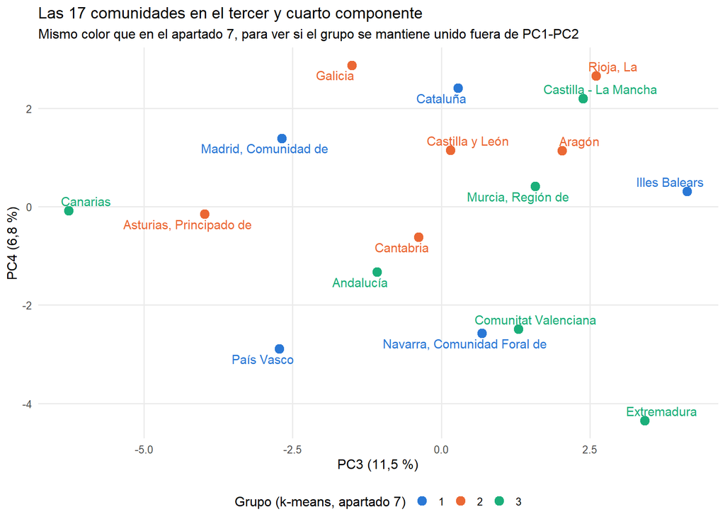

**Figura 22.** Las 17 comunidades autónomas en el tercer y el cuarto componente principal, con los colores de los grupos del apartado 7.

**Tabla 28.** Indicadores con más peso en cada extremo del tercer y el cuarto componente principal.

Los 6 indicadores con más peso en cada extremo de PC3 y PC4

| Componente | Indicadores del extremo negativo | Indicadores del extremo positivo |
| --- | --- | --- |
| PC3 | Desigualdad S80/S20; Limit. actividad: leve; Empleo parcial involuntario; Form. 65+: nivel 5-8; Satisf. trabajo 5-6; PM10 días superación | Form. 25-64: nivel 0-2; IMC: sobrepeso; Form. 65+: nivel 0-2; Satisf. trabajo (media); Satisf. vivienda: muy satisf.; Fumadores diarios |
| PC4 | Trabajo temporal; Formación continua 25-64; Ejercicio físico regular; Empleo parcial involuntario; Satisfacción vital; Fumadores diarios | IMC: sobrepeso; Nec. médicas: otras razones; IMC: bajo peso; Jornada larga 40-48h; Tasa de homicidios; Satisf. trabajo 0-4 |

A diferencia de PC1 y PC2, estos dos ejes no tienen una lectura tan limpia: en sus extremos se mezclan indicadores de desigualdad, contaminación y empleo parcial involuntario con hábitos de salud, tabaquismo y satisfacción laboral, sin que una sola idea los explique todos. Eso ya es parte del resultado: no todo lo que separa a las comunidades españolas cabe en “nivel socioeconómico” o “dinamismo demográfico”.

**Illes Balears sigue siendo un caso extremo, pero el grupo del apartado 7 se deshace.** En PC3, Illes Balears tiene el valor más alto de las 17 comunidades (4,14). Pero sus cuatro compañeros del Grupo 1 (Cataluña, Madrid, Navarra y País Vasco) ya no están cerca de ella en este eje: se reparten desde País Vasco (el más bajo de los cinco) hasta Illes Balears (con diferencia el más alto). La agrupación limpia del apartado 7 es, sobre todo, un fenómeno de PC1 y PC2; en los ejes con menos peso, esa compañía se disuelve.

## Un vistazo en 3D: los tres primeros componentes a la vez

PC1, PC2 y PC3 juntos ya explican el 68,8 % de la variación entre comunidades, 11,5 puntos más que el plano de solo dos ejes del apartado 7. El siguiente gráfico es interactivo: se puede girar, acercar y pasar el ratón por cada punto.

[interactive chart not shown]

**Figura 23.** Las 17 comunidades autónomas en los tres primeros componentes principales (gráfico interactivo).

Confirma visualmente lo que ya decía la sección anterior: mirado desde arriba (el plano PC1-PC2 de la base) el Grupo 1 se ve compacto, pero al añadir la altura de PC3 sus cinco miembros se separan — Illes Balears es, con diferencia, el que más sube.

## K-means con 4 grupos en vez de 3

**Por qué probar con uno más.** El apartado 7 usa 3 grupos porque es el número que da una partición legible con 17 casos. Pedirle uno más al algoritmo sirve para ver si el grupo de 5 comunidades del apartado 7 —la España de mayor nivel socioeconómico— es en realidad homogéneo, o si esconde una división interna que 3 grupos no dejaba ver.

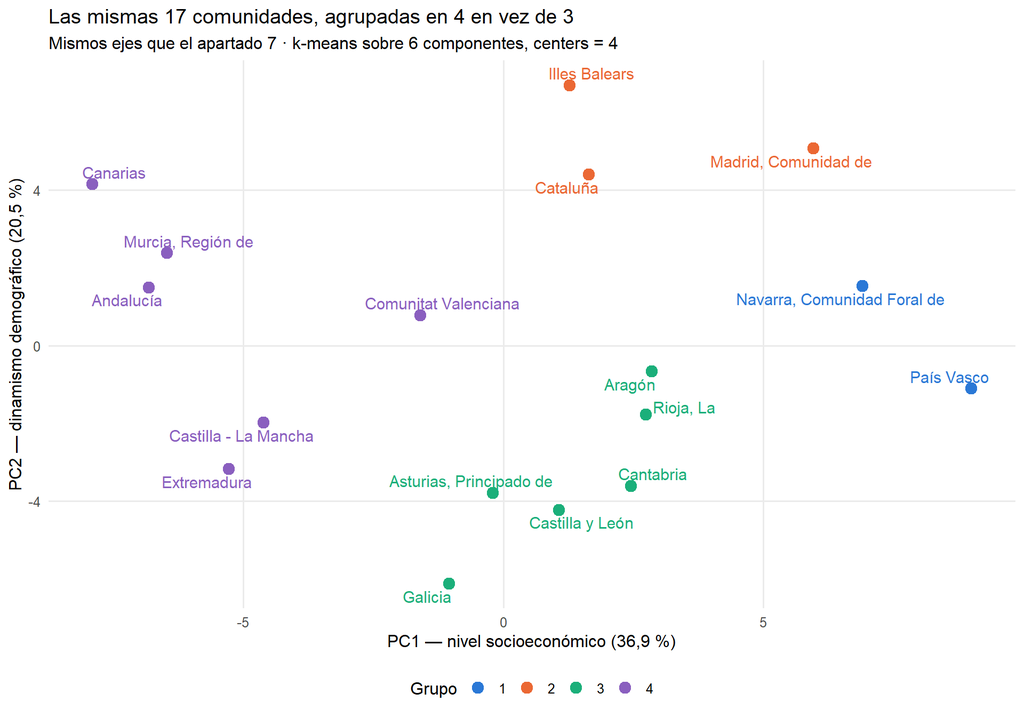

**Figura 24.** Las 17 comunidades autónomas agrupadas por k-means en 4 grupos, sobre los mismos ejes que la agrupación del apartado 7.

**Tabla 29.** Los cinco miembros del Grupo 1 del apartado 7 en la agrupación en 4 grupos.

El antiguo Grupo 1 se parte en dos

Los 5 miembros de la España de mayor nivel socioeconómico del apartado 7, ahora en dos grupos

| CCAA | Grupo | Renta media real (€ de 2023) | PIB per cápita real (€ de 2023) | Form. superior 25-64 (%) | Compra (€/m² de 2024) | Criminalidad (por 1.000 hab.) | Crec. población 2000-2023 (%) | PC2 (dinamismo) |
| --- | --- | --- | --- | --- | --- | --- | --- | --- |
| Navarra, Comunidad Foral de | 1 | 25.952 | 36.908 | 48,4 | 1.974 | 50 | 23,6 | 1,53 |
| País Vasco | 1 | 26.743 | 38.205 | 55 | 3.056 | 46 | 5,6 | −1,11 |
| Cataluña | 2 | 24.057 | 35.436 | 43,6 | 2.516 | 60,7 | 26,2 | 4,39 |
| Illes Balears | 2 | 21.738 | 33.550 | 34,6 | 3.271 | 63,4 | 43,1 | 6,69 |
| Madrid, Comunidad de | 2 | 25.712 | 41.591 | 50,2 | 3.211 | 56,5 | 32 | 5,08 |

Al pedir un grupo más, el algoritmo deja intactos los otros dos grupos del apartado 7 — ninguna de las 12 comunidades de la España de nivel socioeconómico intermedio ni de la de menor nivel cambia de sitio— y concentra todo el cambio en el antiguo Grupo 1: sus 5 comunidades se dividen en **Illes Balears, Cataluña y Madrid**, por un lado, y **Navarra y País Vasco**, por otro.

**La línea de corte es el dinamismo, no la riqueza.** La renta de Madrid (25.712 € de 2023) es muy parecida a la de Navarra (25.952 €) y País Vasco (26.743 €), y Madrid tiene además el PIB por habitante más alto de los cinco, así que no es la riqueza lo que separa a los dos subgrupos. Lo que los separa es el segundo eje del PCA, el del dinamismo demográfico. Illes Balears, Madrid y Cataluña han ganado entre un 26 % y un 43 % de población desde 2000, tienen más delitos por habitante (entre 56 y 63 por 1.000) y están en lo alto de PC2. Navarra ha crecido algo menos (24 %) y País Vasco casi nada (6 %); tienen menos criminalidad (entre 46 y 50) y están cerca del centro del eje. Es otra forma de ver el hallazgo del apartado 6: dentro de la España de mayor nivel socioeconómico, lo que más distingue a Illes Balears de Navarra o País Vasco no es tanto la riqueza como la presión de una población que crece.

Esto no convierte 4 en “el número correcto”. La parte de la variación que explican los grupos siempre sube al añadir uno más (aquí, del 50,9 % con 3 grupos al 60,8 % con 4), así que eso no demuestra nada. El coeficiente de silueta medio, que no mejora de forma automática, pasa de 0,24 a 0,27: una mejora modesta, coherente con partir en dos un grupo que ya existía y no con haber descubierto una estructura nueva. Con los dos valores por debajo de 0,5, lo honesto es decir que en ambos casos los grupos existen pero están poco separados. Se enseña como comprobación, no como corrección del apartado 7.

## Agrupación jerárquica como alternativa

**Qué hace.** En vez de fijar de entrada cuántos grupos hay, este método va fusionando las dos comunidades (o grupos de comunidades) más parecidas, una y otra vez, hasta que todas acaban en un único grupo. El resultado es un árbol (**dendrograma**): cortarlo a una altura da 2 grupos, a otra da 3, a otra da 4… El número de grupos no hace falta decidirlo antes de ver los datos, solo elegir a qué altura se corta el árbol.

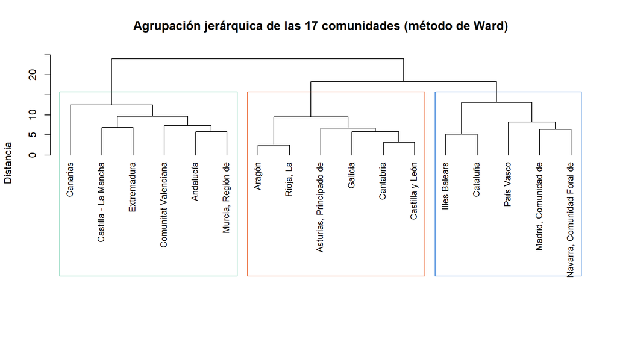

**Figura 25.** Agrupación jerárquica (dendrograma) de las 17 comunidades autónomas, cortada en 3 grupos.

**Cortado en 3 grupos, este método reproduce exactamente la partición de k-means del apartado 7** — las mismas 5, 6 y 6 comunidades, sin que ni una sola cambie de grupo. Dos algoritmos completamente distintos, con principios de partida distintos, llegan al mismo sitio: es la comprobación de robustez más fuerte de todo este anexo.

Cortado en 4 grupos, sin embargo, traza la frontera en un sitio distinto del de k-means: separa a **Illes Balears y Cataluña** de **Madrid, Navarra y País Vasco**, en vez de dejar a Madrid con Illes Balears y Cataluña como hacía k-means. Los otros dos grupos (la España de nivel socioeconómico intermedio y la de menor nivel) no cambian. La diferencia está en una sola comunidad, Madrid, y tiene explicación: Madrid es la bisagra del grupo, rica como Navarra y País Vasco y dinámica como Illes Balears y Cataluña, así que cae de un lado o del otro según qué pese más en cada método. La lectura, por tanto, es doble: el reparto en 3 grupos es sólido, porque dos métodos muy distintos coinciden; la forma concreta de partir en dos la España de mayor nivel socioeconómico no lo es.

## Qué significa todo este anexo

**La mayoría de las comprobaciones confirman el informe, no lo contradicen.** La agrupación jerárquica reproduce exactamente el k-means del apartado 7. Al pedir 4 grupos, k-means y el método jerárquico parten en dos la España de mayor nivel socioeconómico y solo discrepan en una comunidad, Madrid, que está a medio camino entre las más ricas (Navarra, País Vasco) y las más dinámicas (Illes Balears, Cataluña). Lo que sí deja claro el anexo es que los grupos, aunque estables, están poco separados: la frontera exacta dentro de ese grupo depende del método. En conjunto, este anexo aumenta la confianza en los apartados 6 y 7 más de lo que la resta.

# Anexo E · Análisis de rutas: ¿depende el resultado de una sola comunidad?

Con solo 17 comunidades, una sola comunidad atípica puede mover mucho un coeficiente de ruta. Para comprobarlo se repite cada modelo de los apartados 9 y 10 **17 veces, quitando cada vez una comunidad distinta**. El punto es el coeficiente con las 17; la barra horizontal, el rango de valores que toma al quitar una comunidad cada vez; el rombo naranja, el valor que se obtiene al quitar **Illes Balears**.

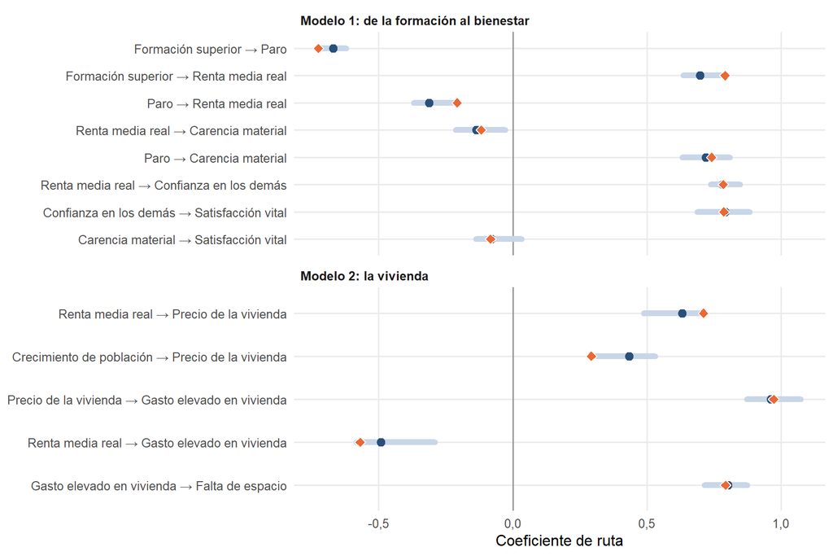

**Figura 26.** Coeficiente de cada flecha de los dos modelos de rutas con las 17 comunidades (punto) y rango de valores que toma al quitar cada vez una comunidad (barra); el rombo naranja es el coeficiente sin Illes Balears.

**Tabla 30.** Coeficiente de cada flecha con las 17 comunidades y sin Illes Balears, y valores mínimo y máximo al quitar cada vez una comunidad (indicando cuál).

| Modelo | Flecha | Con las 17 | Sin Illes Balears | Mínimo | (al quitar) | Máximo | (al quitar) |
| --- | --- | --- | --- | --- | --- | --- | --- |
| Modelo 1 | Formación superior → Paro | −0,67 | −0,72 | −0,72 | Illes Balears | −0,62 | Extremadura |
| Modelo 1 | Formación superior → Renta media real | 0,70 | 0,79 | 0,64 | Madrid, Comunidad de | 0,79 | Illes Balears |
| Modelo 1 | Paro → Renta media real | −0,31 | −0,21 | −0,37 | Madrid, Comunidad de | −0,21 | Illes Balears |
| Modelo 1 | Renta media real → Carencia material | −0,13 | −0,12 | −0,21 | Madrid, Comunidad de | −0,03 | País Vasco |
| Modelo 1 | Paro → Carencia material | 0,72 | 0,74 | 0,63 | Canarias | 0,81 | Murcia, Región de |
| Modelo 1 | Renta media real → Confianza en los demás | 0,78 | 0,78 | 0,74 | País Vasco | 0,85 | Asturias, Principado de |
| Modelo 1 | Confianza en los demás → Satisfacción vital | 0,79 | 0,79 | 0,69 | Navarra, Comunidad Foral de | 0,88 | Asturias, Principado de |
| Modelo 1 | Carencia material → Satisfacción vital | −0,08 | −0,08 | −0,14 | Cantabria | 0,03 | Asturias, Principado de |
| Modelo 2 | Renta media real → Precio de la vivienda | 0,63 | 0,71 | 0,49 | País Vasco | 0,71 | Illes Balears |
| Modelo 2 | Crecimiento de población → Precio de la vivienda | 0,43 | 0,29 | 0,29 | Illes Balears | 0,53 | País Vasco |
| Modelo 2 | Precio de la vivienda → Gasto elevado en vivienda | 0,96 | 0,97 | 0,87 | Madrid, Comunidad de | 1,07 | Asturias, Principado de |
| Modelo 2 | Renta media real → Gasto elevado en vivienda | −0,49 | −0,57 | −0,58 | Asturias, Principado de | −0,29 | Canarias |
| Modelo 2 | Gasto elevado en vivienda → Falta de espacio | 0,80 | 0,79 | 0,71 | Canarias | 0,87 | Asturias, Principado de |

**Qué se ve.** Solo cambia de signo al quitar alguna comunidad la flecha Carencia material → Satisfacción vital, que ya se había identificado como débil (gris en el diagrama); ninguna de las flechas que se sostienen cambia de signo, y las flechas sólidas del modelo 1 apenas se mueven. Las dos flechas más sensibles son las del modelo 2: la de la **renta al gasto elevado**, que ya era la menos segura, y la del **crecimiento de la población al precio**. En esta última, la comunidad que más la mueve es precisamente Illes Balears: sin ella, el efecto se reduce a 0,29. Es lo que se comentó en el apartado 10: la relación entre la llegada de población y el precio se apoya en buena parte en el caso balear, y por eso conviene leerla con cautela.

# Anexo F · ¿Y si se resume todo en una sola cifra? Un indicador sintético

A lo largo del informe la calidad de vida se ha analizado indicador a indicador y dimensión a dimensión. Una alternativa natural es **agregar de alguna manera los indicadores para obtener un único indicador de síntesis de la calidad de vida**, una sola cifra por comunidad que permita ordenarlas de mejor a peor. Este anexo construye ese indicador, compara su resultado con el índice oficial que publica el INE y explica por qué el informe ha preferido una aproximación multidimensional en lugar de un valor de síntesis.

## Cómo se construye el indicador sintético

Se parte de diez indicadores: los nueve que describen los grupos del apartado 7 más la esperanza de vida, un indicador clave en salud pública que el INE incluye también en su propio indicador sintético (el IMCV, que se compara más abajo), como primer indicador de la dimensión de salud. Con cada uno se hace lo mismo:

1. Se toma su valor normal en cada comunidad: la mediana de los últimos cinco años, como en el resto del informe.
2. Se **tipifica cada indicador por separado**: a su valor en cada comunidad se le resta la media de ese mismo indicador en las 17 comunidades, y el resultado se divide por la desviación típica de ese indicador en esas 17. La cifra que sale dice a cuántas desviaciones típicas de la media está cada comunidad en ese indicador; así todos quedan en la misma escala y se pueden sumar euros con porcentajes. Es parecido al z-score del apartado 4, con una diferencia: allí se comparaba Illes Balears con la media y la desviación típica de las *otras 16*; aquí cada comunidad se compara con las 17.
3. Se **ajusta el signo según su polaridad**: en los indicadores en los que subir es malo (paro, abandono, precios de la vivienda, criminalidad) se cambia el signo, para que en todos un valor positivo signifique “mejor que la media”.
4. El indicador sintético es el **promedio** de las diez puntuaciones ajustadas, todas con el mismo peso. Vale 0 en una comunidad que esté justo en la media en todo, y es positivo o negativo según quede por encima o por debajo en el conjunto.

**Tabla 31.** Los diez indicadores del indicador sintético y el sentido con el que entra cada uno.

| Indicador | Que suba es | Illes Balears (valor tipificado ajustado) |
| --- | --- | --- |
| Renta media real | bueno: se mantiene el signo | 0,17 |
| PIB per cápita real | bueno: se mantiene el signo | 0,61 |
| Tasa de paro | malo: se le cambia el signo | 0,52 |
| Tasa de empleo | bueno: se mantiene el signo | 1,73 |
| Abandono educativo 18-24 | malo: se le cambia el signo | −1,47 |
| Salud: muy buena | bueno: se mantiene el signo | 1,63 |
| Esperanza de vida | bueno: se mantiene el signo | −0,13 |
| Precio compraventa (€/m²) | malo: se le cambia el signo | −1,85 |
| Precio alquiler (€/m²/mes) | malo: se le cambia el signo | −1,06 |
| Tasa de criminalidad | malo: se le cambia el signo | −2 |

*Que suba es*: verde, subir es bueno; morado, subir es malo. *Illes Balears (valor tipificado ajustado)*: valor tipificado con el signo ya ajustado según la polaridad; verde, Illes Balears está mejor que la media de las comunidades en ese indicador; rojo, peor; más intenso cuanto más lejos.

## Qué dice

[interactive chart not shown]

**Figura 27.** Indicador sintético de calidad de vida de las 17 comunidades autónomas: promedio de las puntuaciones tipificadas de diez indicadores, con el signo ajustado según su polaridad (mediana de los últimos 5 años). Color: grupo del apartado 7; Illes Balears, con borde naranja.

Con este indicador, Illes Balears queda en el **puesto 13 de 17** (-0,19), por debajo de la media, y es la única comunidad del Grupo 1 con un valor negativo: sus cuatro compañeros de grupo están por encima de la media. Las seis comunidades del Grupo 3 están todas en la mitad baja.

## El índice oficial del INE dice otra cosa

El INE ya publica un indicador de síntesis, el **Indicador Multidimensional de Calidad de Vida (IMCV)**, construido con 55 indicadores de las nueve dimensiones (ver el apartado 2.1). Con él, y con la misma ventana de cinco años, Illes Balears está en el **puesto 6 de 17**; desde 2008 nunca ha bajado del puesto 9 ni subido del 4. Los dos índices coinciden en lo grueso (la correlación entre los dos órdenes es de 0,80): arriba, Navarra, La Rioja y Aragón; abajo, Canarias y Andalucía. Donde más discrepan es justo en Illes Balears.

**Tabla 32.** Puesto de cada comunidad según el indicador sintético de diez indicadores, sus variantes sin los precios de la vivienda (y sin la criminalidad) y el índice oficial del INE (IMCV, mediana 2020–2024).

| CCAA | Grupo | Indicador sintético | Puesto (10 indicadores) | Puesto sin precios | Puesto sin precios ni criminalidad | Puesto IMCV (INE) |
| --- | --- | --- | --- | --- | --- | --- |
| Navarra, Comunidad Foral de | 1 | 0,671 | 1 | 2 | 2 | 1 |
| Rioja, La | 2 | 0,411 | 2 | 5 | 7 | 2 |
| Aragón | 2 | 0,405 | 3 | 4 | 6 | 3 |
| País Vasco | 1 | 0,355 | 4 | 3 | 3 | 5 |
| Madrid, Comunidad de | 1 | 0,312 | 5 | 1 | 1 | 9 |
| Castilla y León | 2 | 0,254 | 6 | 9 | 9 | 10 |
| Cantabria | 2 | 0,196 | 7 | 7 | 8 | 4 |
| Cataluña | 1 | 0,043 | 8 | 6 | 4 | 11 |
| Galicia | 2 | −0,071 | 9 | 11 | 11 | 15 |
| Asturias, Principado de | 2 | −0,076 | 10 | 10 | 12 | 7 |
| Comunitat Valenciana | 3 | −0,124 | 11 | 12 | 10 | 8 |
| Castilla - La Mancha | 3 | −0,173 | 12 | 13 | 14 | 12 |
| Illes Balears | 1 | −0,186 | 13 | 8 | 5 | 6 |
| Murcia, Región de | 3 | −0,198 | 14 | 14 | 13 | 14 |
| Extremadura | 3 | −0,31 | 15 | 15 | 16 | 13 |
| Canarias | 3 | −0,654 | 16 | 16 | 15 | 17 |
| Andalucía | 3 | −0,858 | 17 | 17 | 17 | 16 |

La diferencia la explican sobre todo **los dos precios de la vivienda**, que el IMCV no incluye. En Illes Balears los dos son de los más altos de España y, con el signo cambiado, restan juntos 0,29 puntos al indicador. Sin ellos, Illes Balears sube al **puesto 8**, y sin los precios ni la criminalidad (que, como se vio en el apartado 4, el turismo probablemente infla), al **puesto 5**. Es decir: por lo que miden los indicadores clásicos de calidad de vida, Illes Balears está en la mitad alta de España; lo que la hunde en un índice que incluye el coste de la vivienda es precisamente ese coste. Es la misma tijera que describe el informe, vista ahora a través de una sola cifra.

## Por qué el informe no se apoya en un único valor de síntesis

Un indicador sintético es muy útil para comunicar: una sola cifra, un solo orden, fácil de recordar. Pero este informe ha preferido una **aproximación multidimensional** —mirar cada indicador, su nivel y su tendencia, y después cómo se agrupan y se relacionan— por varias razones que este mismo anexo ilustra:

En resumen, el indicador sintético es un buen complemento para resumir y comunicar, siempre que se diga de qué está hecho, y confirma el mensaje central del informe: la singularidad de Illes Balears no es una calidad de vida baja en general, sino la distancia entre lo que ofrece y lo que cuesta vivir en las islas.